# **Loan Default Prediction**

## **Problem Definition**

### **The Context:**

Loan defaults pose a significant threat to a bank’s financial health. For instance, while the mortgage delinquency rate in the United States has been gradually declining since the COVID-19 pandemic, as of February 2024, the overall delinquency rate was 2.8%. Such non-performing assets (NPAs) erode profitability and constrain the bank’s ability to extend new credit. Moreover, the manual loan approval process is labor-intensive and susceptible to human errors and biases, leading to potential misjudgments in loan approvals or rejections. Addressing this issue is crucial to enhance operational efficiency, reduce financial risks, and uphold equitable lending practices.

### **The objective:**

The goal is to modernize and streamline the loan approval process by leveraging machine learning classification methods, capable of as accurately predicting loan defaults as possible using available data. This model should:

- Enhance operational efficiency by automating repetitive tasks and reducing the time spent on manual credit assessments.
- Mitigate risk by identifying high-risk applicants before loan issuance.
- Ensure fairness by eliminating biases that could disadvantage certain demographics, thus aligning with federal regulation, legal requirements and ethical standards.
- Ensure Regulatory Compliance by aligning with legal frameworks such as the Equal Credit Opportunity Act, which mandates non-discriminatory lending practices and requires transparent justifications for adverse decisions.
- Enable data-driven decision-making by providing interpretable insights into why a loan is approved or rejected, allowing for greater transparency and trust with stakeholders.
- Promote Fairness by eliminating biases inherent in human judgment, ensuring equitable treatment of all applicants.
- The model should be extensible to learn from future loan defaults

### **The key questions:**

- Which applicants are likely to default on their loans? Identifying potential defaulters enables targeted risk management strategies.
- What factors are most critical in assessing an applicant’s creditworthiness? Determining key indicators such as income stability, debt-to-income ratio, and credit history informs more accurate evaluations.
- How can the loan approval process be optimized for efficiency and fairness? Implementing automated, data-driven systems can streamline operations while upholding ethical standards.
- How can the model ensure compliance with regulatory requirements? Providing interpretable justifications for loan decisions is essential to meet legal obligations and maintain transparency.
- How can historical biases be prevented from influencing the model? Ensuring the model is trained on unbiased data is crucial to avoid perpetuating past discriminatory practices.

### **The problem formulation**:

Data science enables us to:

- Predict defaults: Use predictive analytics to assess the likelihood of applicants failing to meet their repayment obligations.
- Automate Decision-Making: Replace subjective human assessments with objective, data-driven evaluations, enhancing consistency and speed.
- Identify Key Risk Factors: Analyze data to pinpoint variables that significantly influence default risk, such as high debt-to-income ratios or unstable employment histories.
- Ensure Model Interpretability: Develop transparent models that provide clear explanations for their decisions, facilitating compliance with regulations and building stakeholder trust.
- Mitigate Bias: Implement fairness algorithms to detect and correct biases, ensuring the model’s decisions are equitable and just.

By solving this problem, the bank not only reduces risk but also transforms its loan approval system into a benchmark for innovation and inclusivity.

## **Data Description:**

The Home Equity dataset (HMEQ) contains baseline and loan performance information for 5,960 recent home equity loans. The target (BAD) is a binary variable that indicates whether an applicant has ultimately defaulted or has been severely delinquent. This adverse outcome occurred in 1,189 cases (20 percent). 12 input variables were registered for each applicant.

- **BAD:** 1 = Client defaulted on loan, 0 = loan repaid
- **LOAN:** Amount of loan approved.
- **MORTDUE:** Amount due on the existing mortgage.
- **VALUE:** Current value of the property.
- **REASON:** Reason for the loan request. (HomeImp = home improvement, DebtCon= debt consolidation which means taking out a new loan to pay off other liabilities and consumer debts)
- **JOB:** The type of job that loan applicant has such as manager, self, etc.
- **YOJ:** Years at present job.
- **DEROG:** Number of major derogatory reports (which indicates a serious delinquency or late payments).
- **DELINQ:** Number of delinquent credit lines (a line of credit becomes delinquent when a borrower does not make the minimum required payments 30 to 60 days past the day on which the payments were due).
- **CLAGE:** Age of the oldest credit line in months.
- **NINQ:** Number of recent credit inquiries.
- **CLNO:** Number of existing credit lines.
- **DEBTINC:** Debt-to-income ratio (all your monthly debt payments divided by your gross monthly income. This number is one way lenders measure your ability to manage the monthly payments to repay the money you plan to borrow.

## **Import the necessary libraries and Data**

```python
import time
import warnings
import gc
import copy
import math

# Data manipulation and analysis
import pandas as pd
import numpy as np

# Data visualization
import matplotlib.pyplot as plt
import seaborn as sns

# Preprocessing and dimensionality reduction
from sklearn.preprocessing import StandardScaler
from sklearn.decomposition import PCA

# Model selection and training
from sklearn.model_selection import train_test_split, GridSearchCV
from sklearn.linear_model import LogisticRegression
from sklearn.tree import DecisionTreeClassifier, plot_tree
from sklearn.ensemble import RandomForestClassifier
from sklearn.model_selection import cross_val_score

# Imputation and missing value handling
from sklearn.experimental import enable_iterative_imputer
from sklearn.impute import IterativeImputer
from fancyimpute import KNN

# Metrics and evaluation
from sklearn.metrics import (
    classification_report, confusion_matrix, accuracy_score,
    precision_score, recall_score, f1_score, precision_recall_curve
)
from statsmodels.stats.outliers_influence import variance_inflation_factor
from scipy.stats import chi2_contingency

# Ignore warnings selectively
warnings.filterwarnings("ignore")
warnings.filterwarnings("ignore", message=".*Some other specific message.*")
warnings.filterwarnings("ignore", message=".*'force_all_finite' was renamed to 'ensure_all_finite'.*")

# Start time
script_start_time = time.time()

# Garbage collection
gc.collect()

# Add any additional functions or utility imports here
```

```
0
```

```python
# Data Processing Functions
def summarize_dataframe(df):
    """
    Summarizes the structure and content of a DataFrame.
    """
    summary = {
        "Column": df.columns,
        "Non-Null Count": df.notnull().sum(),
        "Data Type": df.dtypes,
        "Unique Values": df.nunique(),
        "Missing Values": df.isnull().sum(),
        "Missing Values %": (df.isnull().sum() / len(df) * 100).round(2),
    }
    return pd.DataFrame(summary).reset_index(drop=True)


def segregate_columns_by_dtype(df):
    """
    Segregates DataFrame columns by their data types.
    """
    return {dtype.name: df.select_dtypes(include=[dtype]).columns.tolist() for dtype in df.dtypes.unique()}


def impute_missing_values(df, knn_cols, iterative_cols, categorical_cols):
    """
    Imputes missing values using KNN and IterativeImputer.
    """
    original_categories = {}

    # Encode categorical columns for KNN
    for col in categorical_cols:
        df[col] = df[col].astype("category")
        original_categories[col] = df[col].cat.categories
        df[col] = df[col].cat.codes.replace(-1, np.nan)

    # Impute with KNN
    df[knn_cols] = KNN(k=5, verbose=False).fit_transform(df[knn_cols])

    # Impute with IterativeImputer
    df[iterative_cols] = IterativeImputer(max_iter=10, random_state=42).fit_transform(df[iterative_cols])

    return df, original_categories


def decode_categorical_columns(df, original_categories):
    """
    Decodes categorical columns back to original values.
    """
    for col, categories in original_categories.items():
        df[col] = pd.Categorical.from_codes(df[col], categories)
    return df


def calculate_corr_and_vif(df, target):
    """
    Calculates correlation matrix and VIF for numerical features.
    """
    df = df.drop(columns=[target], errors="ignore")
    numeric_df = df.select_dtypes(include=[np.number])

    corr_matrix = numeric_df.corr()
    vif_data = pd.DataFrame({
        "Feature": numeric_df.columns,
        "VIF": [variance_inflation_factor(numeric_df.values, i) for i in range(numeric_df.shape[1])]
    })
    return corr_matrix, vif_data


# Visualization Functions
def plot_correlation_heatmap(data, title="Correlation Heatmap"):
    """
    Plots a heatmap of correlations in the dataset.
    """
    plt.figure(figsize=(12, 10))
    sns.heatmap(data.corr(), annot=True, fmt=".2f", cmap="coolwarm")
    plt.title(title, fontsize=16)
    plt.show()


def plot_pca(pca_object, title="Cumulative Explained Variance"):
    """
    Plots the cumulative explained variance ratio from a PCA object.
    """
    plt.figure(figsize=(8, 6))
    plt.plot(range(1, len(pca_object.explained_variance_ratio_) + 1),
             np.cumsum(pca_object.explained_variance_ratio_), 'r', marker="o")
    plt.title(title)
    plt.xlabel("Number of Principal Components")
    plt.ylabel("Cumulative Variance Explained")
    # plt.grid()
    plt.show()


def engineer_and_scale_features(data, ratio_cols, new_feature_name, drop_original=True):
    """
    Engineer a new feature as the ratio of two columns, scale it, and optionally drop the original columns.

    Parameters:
        data (pd.DataFrame): Input DataFrame.
        ratio_cols (tuple): A tuple of two column names (numerator, denominator) to compute the ratio.
        drop_original (bool): Whether to drop the original columns after creating the new feature. Default is True.

    Returns:
        pd.DataFrame: DataFrame with the new engineered and scaled feature.
    """
    df = data.copy()

    # Create the new feature
    df[new_feature_name] = df[ratio_cols[0]] / df[ratio_cols[1]]

    # Drop the original columns if specified
    if drop_original:
        df.drop(list(ratio_cols), axis=1, inplace=True)

    # Scale the new feature
    df[new_feature_name] = StandardScaler().fit_transform(df[[new_feature_name]])

    return df


# Model Evaluation Functions
def metrics_score(actual, predicted):
    """
    Calculates classification metrics and plots a confusion matrix.
    """
    print(classification_report(actual, predicted))
    cm = confusion_matrix(actual, predicted)
    plt.figure(figsize=(8, 5))
    sns.heatmap(cm, annot=True, fmt="d", cmap="rainbow_r",
                xticklabels=["Not Defaulted", "Defaulted"],
                yticklabels=["Not Defaulted", "Defaulted"])
    plt.ylabel("Actual")
    plt.xlabel("Predicted")
    plt.title("Confusion Matrix")
    plt.show()

def calculate_expected_with_confidence(data, loan_value_col, interest_rate=0.085):
    """
    Calculate the expected revenue/loss and average confidence from predictions.

    Parameters:
        data (pd.DataFrame): Dataset containing the columns 'prob_default', 'actual', and the loan value column.
        loan_value_col (str): The column name representing the loan values.
        interest_rate (float): The interest rate applied to loans. Default is 8.5%.

    Returns:
        tuple: A tuple containing:
            - Total expected revenue (float)
            - Average confidence level (float)
    """
    # Add P(non-default) = 1 - P(default) to the dataset
    data['prob_non_default'] = 1 - data['prob_default']

    # Calculate confidence scores as the maximum probability of the prediction
    data['confidence'] = data[['prob_default', 'prob_non_default']].max(axis=1)

    # Revenue from True Negatives (TN): Correctly predicted non-defaults
    data['revenue_tn'] = (
        data['prob_non_default']
        * (1 - data['client_defaulted_on_loan'])  # Actual is non-default
        * data['confidence']  # Adjust by confidence level
        * data[loan_value_col]
        * interest_rate
    )

    # Loss from False Positives (FP): Predicted default but actual non-default
    data['loss_fp'] = (
        data['prob_default']
        * (1 - data['client_defaulted_on_loan'])  # Actual is non-default
        * (1 - data['confidence'])  # Adjust by lack of confidence
        * data[loan_value_col]
        * interest_rate
    )

    # Loss from False Negatives (FN): Predicted non-default but actual default
    data['loss_fn'] = (
        data['prob_non_default']
        * data['client_defaulted_on_loan']  # Actual is default
        * (1 - data['confidence'])  # Adjust by lack of confidence
        * data[loan_value_col]
        * (1 + interest_rate)  # Account for the loan principal and interest
    )
```

```python
    # Total revenue = Sum of revenue from TN - Sum of losses from FP and FN
    total_revenue = data['revenue_tn'].sum() - data['loss_fp'].sum() - data['loss_fn'].sum()

    # Average confidence level
    avg_confidence = data['confidence'].mean()

    return total_revenue, avg_confidence


def model_performance_classification(model, predictors, target):
    """
    Evaluates the performance of a classification model.
    """
    pred = model.predict(predictors)
    scores = {
        "Precision": precision_score(target, pred, average="macro"),
        "Recall": recall_score(target, pred, average="macro"),
        "Accuracy": accuracy_score(target, pred),
    }
    return pd.DataFrame([scores])

# Function to evaluate the model and append results
def evaluate_model_and_metrics(
    model, x_test, y_test, X_scaled, default_model, model_name, model_type,
    loan_value_col='loan_amount_approved', grid_search=False
):
    """
    Evaluates the model on test data, calculates metrics, updates the dataset with probabilities,
    and calculates expected revenue and confidence.

    Parameters:
        model: Trained machine learning model.
        x_test (pd.DataFrame): Test set features.
        y_test (pd.Series): Test set labels.
        X_scaled (pd.DataFrame): Scaled dataset used for probability predictions.
        default_model (pd.DataFrame): Original dataset to update with probabilities.
        model_name (str): Name of the model for tracking.
        model_type (str): Type of the model (e.g., Logistic Regression, Random Forest).
        loan_value_col (str): Name of the column representing loan values (default: 'loan_amount_approved').
        grid_search (bool): Whether the model was trained using GridSearchCV. Default is False.

    Returns:
        dict: A dictionary containing evaluation metrics for appending to the model_metrics DataFrame.
    """
    # Make predictions and calculate metrics
    y_pred = model.predict(x_test)
    metrics_score(y_test, y_pred)  # Display classification report and confusion matrix

    # Update probabilities in the dataset
    default_model_copy = default_model.copy()
    pred_prob = model.predict_proba(X_scaled)
    default_model_copy['prob_default'] = pred_prob[:, 1]

    # Calculate expected revenue and confidence
    revenue, confidence = calculate_expected_with_confidence(default_model_copy, loan_value_col)
    print(f"Total expected revenue: {revenue} with confidence of: {confidence}")

    # Generate classification report and confusion matrix
    cr = classification_report(y_test, y_pred, output_dict=True)
    cm = confusion_matrix(y_test, y_pred)

    # Compile metrics into a dictionary
    metrics_dict = {
        'Model Name': model_name,
        'Model Type': model_type,
        'Grid Search (Yes/No)': 'Yes' if grid_search else 'No',
        'Recall': cr['1']['recall'],
        'Precision': cr['1']['precision'],
        'f1': cr['1']['f1-score'],
        'Accuracy': cr['accuracy'],
        'FPs': cm[0][1],
        'FNs': cm[1][0],
        'Revenue Prediction': revenue,
        'Confidence': confidence,
    }

    return metrics_dict

# Data Visualization Functions
def plot_grouped_barplots(data, features, target, figsize=(15, 6)):
    """
    Plots grouped barplots for a list of features against a target variable.
    """
    n_cols = 3
    n_rows = math.ceil(len(features) / n_cols)

    fig, axes = plt.subplots(n_rows, n_cols, figsize=(figsize[0], figsize[1] * n_rows))
    axes = axes.flatten()

    for i, feature in enumerate(features):
        grouped_data = data.groupby(feature, observed=True)[target].sum().reset_index()
        sns.barplot(x=feature, y=target, data=grouped_data, ax=axes[i], color='green')
        axes[i].set_title(f"{target} by {feature}")
        axes[i].tick_params(axis="x", rotation=90)

    for j in range(len(features), len(axes)):
        axes[j].axis("off")

    plt.tight_layout()
    plt.show()

def plot_histogram(data, column, bins=None, xlabel=None, ylabel='Count', title=None, grid=True):
    """
    Plots a histogram for a given column with customizable bins and styling.

    Parameters:
    - data (pd.DataFrame): The DataFrame containing the data.
    - column (str): The name of the column to plot.
    - bins (int, list, or np.ndarray, optional): Custom bins for the histogram. Default is None.
    - xlabel (str, optional): Label for the x-axis. Default is the column name.
    - ylabel (str, optional): Label for the y-axis. Default is 'Count'.
    - title (str, optional): Title of the histogram. Default is None.
    - grid (bool, optional): Whether to show gridlines. Default is True.
    """
    plt.figure(figsize=(10, 6))
    plt.hist(data[column], bins=bins, color='green', edgecolor='black', alpha=0.7)

    # Set axis labels and title
    plt.xlabel(xlabel if xlabel else column)
    plt.ylabel(ylabel)
    plt.title(title if title else f'Histogram of {column}')

    # Add grid styling
    if grid:
        plt.grid(axis='y', linestyle='--', alpha=0.7)

    plt.show()

def histogram_boxplot(data, feature, figsize=(12, 7), kde=True, bins=None):
    """
    Combines a boxplot and histogram for a given feature in the dataset.

    Parameters:
    - data (pd.DataFrame): The input dataset.
    - feature (str): The feature to plot.
    - figsize (tuple): Size of the figure (default: (12, 7)).
    - kde (bool): Whether to show a kernel density estimate on the histogram (default: True).
    - bins (int, list, or np.ndarray): Number of bins or edges for the histogram (default: None).
    """
    # Create the subplots for boxplot and histogram
    f2, (ax_box2, ax_hist2) = plt.subplots(
        nrows=2,         # Number of rows in the subplot grid
        sharex=True,     # x-axis will be shared among all subplots
        gridspec_kw={"height_ratios": (0.25, 0.75)},
        figsize=figsize, # Figure size
    )

    # Boxplot with the mean indicated
    sns.boxplot(data=data, x=feature, ax=ax_box2, showmeans=True, color="red")
    ax_box2.set_title(f"Boxplot of {feature}")
```

```python
    # Automatically calculate bins if not provided
    if bins is None:
        q75, q25 = data[feature].quantile([0.75, 0.25])  # Interquartile range
        iqr = q75 - q25
        bin_width = 2 * iqr / (len(data[feature]) ** (1 / 3))  # Freedman-Diaconis rule
        bin_width = max(bin_width, 1)  # Ensure minimum bin width of 1
        bins = int((data[feature].max() - data[feature].min()) / bin_width)
        bins = max(bins, 1)  # Ensure at least 1 bin

    # Histogram
    sns.histplot(data=data, x=feature, kde=kde, ax=ax_hist2, bins=bins, color="green", alpha=0.6)
    ax_hist2.set_title(f"Histogram of {feature}")
    ax_hist2.set_xlabel(feature)
    ax_hist2.set_ylabel("Count")

    # Add mean and median lines to the histogram
    mean = data[feature].mean()
    median = data[feature].median()
    ax_hist2.axvline(mean, color="green", linestyle="--", label=f"Mean: {mean:.2f}")
    ax_hist2.axvline(median, color="black", linestyle="-", label=f"Median: {median:.2f}")
    ax_hist2.legend()

    # Ensure the x-axis starts at 0 (optional, adjust as needed)
    ax_hist2.set_xlim(left=0)

    plt.tight_layout()
    plt.show()

def plot_categorical_distributions(data, categorical_columns, cols_per_row=3, figsize=(15, 5)):
    """
    Plots the distribution of categorical columns in the given dataset.

    Parameters:
    - data (pd.DataFrame): The dataset containing categorical columns.
    - categorical_columns (list): List of categorical column names to plot.
    - cols_per_row (int): Number of subplots per row. Default is 3.
    - figsize (tuple): Base size of the figure. Default is (15, 5).

    Returns:
    - None: Displays the plots.
    """
    # Determine the number of rows and columns for subplots
    num_cols = len(categorical_columns)
    num_rows = math.ceil(num_cols / cols_per_row)

    # Create subplots
    fig, axes = plt.subplots(num_rows, cols_per_row, figsize=(figsize[0], figsize[1] * num_rows))
    axes = axes.flatten()  # Flatten the axes array for easy iteration

    # Plot each categorical column
    for i, col in enumerate(categorical_columns):
        sns.histplot(data, x=col, ax=axes[i], color='green')  # Use the corresponding subplot axis
        axes[i].set_title(f"Histogram for {col}")
        total = len(data[col])

        # Add percentage annotations
        for bar in axes[i].patches:
            height = bar.get_height()
            percentage = (height / total) * 100  # Calculate percentage
            axes[i].text(bar.get_x() + bar.get_width() / 2, height, f'{percentage:.1f}%',
                         ha='center', va='bottom', fontsize=10)
        sns.despine()

    # Hide unused subplots
    for j in range(i + 1, len(axes)):
        axes[j].set_visible(False)

    # Adjust layout and display the plots
    plt.tight_layout()
    plt.show()

def plot_binned_features(data, features, status, bins=5, title=None):
    """
    Plots subplots for binned bar charts of multiple features against a status variable.

    Parameters:
        data (pd.DataFrame): The dataset containing the features and status.
        features (list): A list of continuous variables to be binned and plotted.
        status (str): The variable to sum for each bin, plotted on the y-axis.
        bins (int): Number of bins to create for the features.
        title (str, optional): Title of the overall plot. Default is None.

    Returns:
        None: Displays the subplots.
    """
    # Calculate the grid dimensions
    n_rows, n_cols = 6, 2  # Fixed number of rows and columns
    total_subplots = n_rows * n_cols
    num_features = len(features)

    # Create a figure with subplots
    fig, axes = plt.subplots(nrows=n_rows, ncols=n_cols, figsize=(20, 15))
    fig.suptitle(title if title else f"Features vs {status}", fontsize=16)

    # Flatten axes for easy indexing
    axes = axes.flatten()

    # Iterate over features and create plots
    for i, feature in enumerate(features):
        ax = axes[i]

        # Group by feature and calculate the sum of the status variable
        grouped_data = data.groupby(feature)[status].sum().reset_index()

        # Create bins for the feature
        grouped_data['feature_bin'] = pd.cut(grouped_data[feature], bins=bins)

        # Group by bins and calculate the sum of the status variable
        binned_data = grouped_data.groupby('feature_bin', observed=True)[status].sum().reset_index()

        # Generate bin labels
        bin_edges = grouped_data['feature_bin'].cat.categories
        bin_labels = [f"{int(interval.left)}-{int(interval.right)}" for interval in bin_edges]

        # Bar plot
        sns.barplot(data=binned_data, x='feature_bin', y=status, ax=ax, color='green')

        # Add title and labels
        ax.set_title(f"{feature} vs {status}")
        ax.set_xlabel(f"{feature}")
        ax.set_ylabel(f"{status}")

        # Set x-axis tick labels
        ax.set_xticks(range(len(bin_labels)))
        ax.set_xticklabels(bin_labels, rotation=90)
        total = grouped_data[status].sum()
        for bar in ax.patches:
            height = bar.get_height()
            percentage = (height / total) * 100  # Calculate percentage
            if percentage > 0:
                ax.text(bar.get_x() + bar.get_width() / 2, height, f'{percentage:.1f}%', ha='center', va='bottom', fontsize=10)
        sns.despine()

    # Turn off extra subplots
    for i in range(num_features, total_subplots):
        axes[i].axis('off')

    # Adjust layout and show the plot
    plt.tight_layout(rect=[0, 0, 1, 0.95])
    plt.show()

def plot_feature_importances_or_coefficients(model, X, model_type="general"):
    """
    Plots feature importances or coefficients for a given model,
    accounting for positive and negative coefficients in logistic regression.

    Parameters:
        model: Trained machine learning model.
        X (pd.DataFrame): Feature DataFrame used for training the model.
        model_type (str): Specify "logistic_regression" for logistic regression models
                          or "general" for models with feature_importances_.
```

```python
    Returns:
        None: Displays a bar chart of feature importances or coefficients.
    """
    # Retrieve importances or coefficients based on the model type
    if model_type == "logistic_regression":
        if hasattr(model, "coef_"):
            importances = model.coef_[0] if len(model.coef_.shape) > 1 else model.coef_
            title = "Feature Coefficients (Logistic Regression)"
        else:
            raise ValueError("The provided model does not support coefficients.")
    elif hasattr(model, "feature_importances_"):
        importances = model.feature_importances_
        title = "Feature Importances"
    else:
        raise ValueError("The provided model does not support feature importances or coefficients.")

    # Create DataFrame for sorting and plotting
    importance_df = pd.DataFrame({
        'Feature': X.columns,
        'Importance': importances
    }).sort_values(by='Importance', ascending=False, key=abs if model_type == "logistic_regression" else None)

    # Plotting
    plt.figure(figsize=(12, 6))
    colors = ['green' if val > 0 else 'red' for val in importance_df['Importance']]  # Positive/negative colors
    plt.bar(importance_df['Feature'], importance_df['Importance'], color=colors, align='center')
    plt.xticks(rotation=45, ha='right')
    plt.xlabel('Features')
    plt.ylabel('Importance' if model_type != "logistic_regression" else 'Coefficient')
    plt.title(title)
    plt.axhline(0, color='black', linewidth=0.7, linestyle='--')  # Zero line for logistic regression
    plt.tight_layout()
    plt.show()


def analyze_subset_features(model, x_test, y_test, subset='false_negatives'):
    """
    Analyzes feature values for a specific subset of classification results (e.g., false negatives or false positives),
    and aligns the color palette with the feature importances function.

    Parameters:
        model: Trained classification model.
        x_test (pd.DataFrame): Test set features.
        y_test (pd.Series): Test set labels.
        subset (str): Subset to analyze. Options:
                      - 'false_negatives': Predicted 0, Actual 1
                      - 'false_positives': Predicted 1, Actual 0

    Returns:
        None: Displays a bar chart of mean feature values for the specified subset.
    """
    # Predict probabilities and labels
    y_pred = model.predict(x_test)

    # Compute confusion matrix
    tn, fp, fn, tp = confusion_matrix(y_test, y_pred).ravel()

    # Filter data based on the selected subset
    if subset == 'false_negatives':
        subset_df = x_test[(y_pred == 0) & (y_test == 1)]
        title = "Mean Feature Values for False Negatives"
    elif subset == 'false_positives':
        subset_df = x_test[(y_pred == 1) & (y_test == 0)]
        title = "Mean Feature Values for False Positives"
    else:
        raise ValueError("Invalid subset option. Choose 'false_negatives' or 'false_positives'.")

    # Calculate mean feature values
    subset_features = subset_df.mean().sort_values(ascending=False)

    # Apply colors based on positive/negative values
    colors = ['green' if val > 0 else 'red' for val in subset_features.values]

    # Plot mean feature values
    plt.figure(figsize=(10, 6))
    plt.bar(subset_features.index, subset_features.values, color=colors, align='center')
    plt.title(title, fontsize=14)
    plt.xlabel('Features', fontsize=12)
    plt.ylabel('Mean Value', fontsize=12)
    plt.xticks(rotation=45, ha='right')
    plt.axhline(0, color='black', linewidth=0.7, linestyle='--')  # Zero line for reference
    plt.grid(axis='y', linestyle='--', alpha=0.6)
    plt.tight_layout()
    plt.show()




def chi_squared_test(data, target, bins=5):
    """
    Perform the Chi-Squared test for independence between all features
    and the target variable, handling both categorical and continuous features.

    Parameters:
        data (pd.DataFrame): The input dataset.
        target (str): The name of the target variable.
        bins (int): Number of bins to discretize continuous features. Default is 5.

    Returns:
        pd.DataFrame: A DataFrame containing features, their P-values,
                      and whether they are significant.
    """
    # Separate target column
    target_data = data[target]
    features = data.drop(columns=[target], errors="ignore")

    # List to store results for each feature
    results = []

    for feature in features.columns:
        if features[feature].dtype in ['object', 'category']:
            # Categorical feature: Use directly
            feature_data = features[feature]
        else:
            # Continuous feature: Discretize into bins
            feature_data = pd.cut(features[feature], bins=bins, labels=False)

        # Create a contingency table for the current feature and target
        contingency_table = pd.crosstab(feature_data, target_data)

        # Perform the Chi-Squared test for independence
        chi2, p, dof, expected = chi2_contingency(contingency_table)

        # Append the feature and p-value to the results list
        results.append({'Feature': feature, 'P-value': p, 'Significant': p < 0.05})

    # Convert results to a DataFrame for better visualization
    results_df = pd.DataFrame(results)

    # Sort the results by P-value in ascending order
    sorted_results = results_df.sort_values(by='P-value', ascending=True)

    return sorted_results
```

## **Data Overview**

- Reading the dataset
- Understanding the shape of the dataset
- Checking the data types
- Checking for missing values
- Checking for duplicated values

```python
# Import data from CSV file into a Pandas DataFrame
df = pd.read_csv('../data/hmeq.csv')
```

```python
# Make a copy of the original dataframe for processing, so the original data stays intact
default = df.copy()
```

```python
# Update column names for improved readability
default.rename(columns={
    'BAD': 'client_defaulted_on_loan',  # 1 = Client defaulted on loan, 0 = loan repaid
    'LOAN': 'loan_amount_approved',      # Amount of loan approved
    'MORTDUE': 'mortgage_amount_due',    # Amount due on the existing mortgage
    'VALUE': 'property_current_value',    # Current value of the property
    'REASON': 'loan_request_reason',      # Reason for the loan request
    'JOB': 'applicant_job_type',          # Type of job that loan applicant has
    'YOJ': 'years_at_present_job',        # Years at present job
    'DEROG': 'major_derogatory_reports',  # Number of major derogatory reports
    'DELINQ': 'delinquent_credit_lines',  # Number of delinquent credit lines
    'CLAGE': 'age_of_oldest_credit_line',  # Age of the oldest credit line in months
    'NINQ': 'recent_credit_inquiries',     # Number of recent credit inquiries
    'CLNO': 'existing_credit_lines',       # Number of existing credit lines
    'DEBTINC': 'debt_to_income_ratio'      # Debt-to-income ratio
}, inplace=True)
```

```python
# Check the shape of the dataset
default.shape
```

```
(5960, 13)
```

```python
# Use the summarize_dataframe function and display the summary
summarize_dataframe(default)
```

|  | Column | Non-Null Count | Data Type | Unique Values | Missing Values | Missing Values % |
| --- | --- | --- | --- | --- | --- | --- |
| 0 | client_defaulted_on_loan | 5960 | int64 | 2 | 0 | 0.00 |
| 1 | loan_amount_approved | 5960 | int64 | 540 | 0 | 0.00 |
| 2 | mortgage_amount_due | 5442 | float64 | 5053 | 518 | 8.69 |
| 3 | property_current_value | 5848 | float64 | 5381 | 112 | 1.88 |
| 4 | loan_request_reason | 5708 | object | 2 | 252 | 4.23 |
| 5 | applicant_job_type | 5681 | object | 6 | 279 | 4.68 |
| 6 | years_at_present_job | 5445 | float64 | 99 | 515 | 8.64 |
| 7 | major_derogatory_reports | 5252 | float64 | 11 | 708 | 11.88 |
| 8 | delinquent_credit_lines | 5380 | float64 | 14 | 580 | 9.73 |
| 9 | age_of_oldest_credit_line | 5652 | float64 | 5314 | 308 | 5.17 |
| 10 | recent_credit_inquiries | 5450 | float64 | 16 | 510 | 8.56 |
| 11 | existing_credit_lines | 5738 | float64 | 62 | 222 | 3.72 |
| 12 | debt_to_income_ratio | 4693 | float64 | 4693 | 1267 | 21.26 |

```python
# Check for duplicates and drop if found
num_duplicates = default.duplicated().sum()  # Count duplicates

if num_duplicates > 0:
    print(f"Number of duplicate rows: {num_duplicates}")
    default.drop_duplicates(keep='first', inplace=True)  # Drop duplicates, keeping the first
    print(len(df) - len(default), "Duplicate rows dropped (keeping the first occurrence).")
    default.reset_index(drop=True, inplace=True)  # Reset index after dropping duplicates
else:
    print("No duplicate rows found.")
```

```
No duplicate rows found.
```

```python
# Iterate through each non-numeric column and print its unique values
for column in default.select_dtypes(include=['object']):
    print(f"{column}: {default[column].value_counts()}")
```

```
loan_request_reason: loan_request_reason
DebtCon    3928
HomeImp    1780
Name: count, dtype: int64
applicant_job_type: applicant_job_type
Other      2388
ProfExe    1276
Office      948
Mgr         767
Self        193
Sales       109
Name: count, dtype: int64
```

#### Let's check any inconsitencies in the data

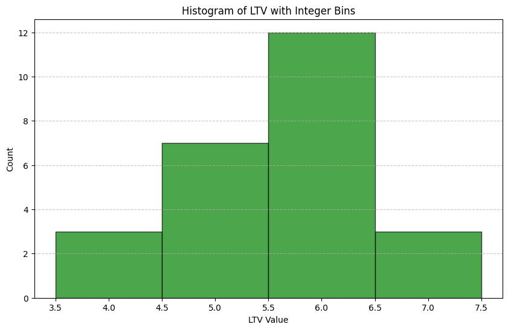

```python
# Check for inconsisties in the data
# Typical mortgage to property value ratio is ~ 0.8. Lets confirm it
default['ltv'] = default['mortgage_amount_due'] / default['property_current_value']  # create a column ltv (loan to value ratio)
high_ltv = default[default['ltv'] >= 2]  # Create a temp dataframe of rows with ltv > 2

# Define bins as integer steps from the min to max value
bins = np.arange(int(high_ltv['ltv'].min()), int(high_ltv['ltv'].max()) + 2) - 0.5

# Plot the count of clients with ltv greater than 2.
plot_histogram(
    data=high_ltv,
    column='ltv',
    bins=bins,
    xlabel='LTV Value',
    ylabel='Count',
    title='Histogram of LTV with Integer Bins'
)
```

```python
# Drop all records with ltv greater than or equal to 2 and the ltv column as it is no longer necessary
default.drop(default[default['ltv'] >= 2].index, axis=0, inplace=True)
default.drop('ltv', axis=1, inplace=True)
```

```python
# delete the temporary dataframe
del high_ltv
# Trigger garbage collection and print the number of objects collected
collected_objects = gc.collect()
print(f"Garbage collector freed {collected_objects} objects.")
```

```
Garbage collector freed 3420 objects.
```

#### Observations

1. Dataset contains several missing values. These need to be treated individually as the use of summary statistic may not be appropriate or sufficient for this this dataset i.e. morgage_amount_due can have missing values,but loan_request_reason or property_current_value cannot be. Also many of the missing values may depend on values in other columns, such as major_derogatory_report, delinquent_credit_lines, recent_credit_inquiries, existing_credit_lines and debt_to_income_ratio are all correlated
2. Features like debt_to_income_ratio and major_derogatory_reports have significant missing values (21.3% and 11.9%, respectively)
3. Dataset has 5960 rows and 13 columns (12 independant features)
4. Data is for approved loans only, as there are no missing values in the loan_amount_approved
5. No duplicate records, which is understandable, as most individuals or families requesting for loan are unique
6. All categorical values look clean - no typos, unique values and consistent labeling
7. Many of the features should be integrers, but are floats in the dataset - major_derogatory_reports, delinquent_credir_lines, recent_credit_inquiries and existing_credit_lines. If the actual values, indeed are floats, its a data descripency which should be addresses before further processing
8. Proportion of defaulting client is 20%, which is too high by industry standards, indicating a highly biased dataset
9. Several records had a very high loan to value ratio. This is quite unusual. All the records with ltv > 2.0 were dropped
10. Also, the features applicant job type and years at present job, may invite discimatory litigation (class action lawsuits)!

## Summary Statistics

```python
# Review the key statistics of the data, transposed for better readability
default.describe().T
```

|  | count | mean | std | min | 25% | 50% | 75% | max |
| --- | --- | --- | --- | --- | --- | --- | --- | --- |
| client_defaulted_on_loan | 5935.0 | 0.200168 | 0.400160 | 0.000000 | 0.000000 | 0.000000 | 0.000000 | 1.000000 |
| loan_amount_approved | 5935.0 | 18561.988206 | 11200.374986 | 1100.000000 | 11000.000000 | 16300.000000 | 23200.000000 | 89900.000000 |
| mortgage_amount_due | 5417.0 | 73262.529297 | 43603.499047 | 2063.000000 | 46145.000000 | 65000.000000 | 91165.000000 | 399550.000000 |
| property_current_value | 5823.0 | 102076.174659 | 57318.611176 | 8800.000000 | 66356.000000 | 89508.000000 | 120076.500000 | 855909.000000 |
| years_at_present_job | 5420.0 | 8.948847 | 7.580495 | 0.000000 | 3.000000 | 7.000000 | 13.000000 | 41.000000 |
| major_derogatory_reports | 5234.0 | 0.255445 | 0.847369 | 0.000000 | 0.000000 | 0.000000 | 0.000000 | 10.000000 |
| delinquent_credit_lines | 5362.0 | 0.446475 | 1.127495 | 0.000000 | 0.000000 | 0.000000 | 0.000000 | 15.000000 |
| age_of_oldest_credit_line | 5627.0 | 179.837880 | 85.884097 | 0.000000 | 115.133546 | 173.214284 | 231.976301 | 1168.233561 |
| recent_credit_inquiries | 5425.0 | 1.181014 | 1.728654 | 0.000000 | 0.000000 | 1.000000 | 2.000000 | 17.000000 |
| existing_credit_lines | 5713.0 | 21.217574 | 10.041934 | 0.000000 | 14.000000 | 20.000000 | 26.000000 | 71.000000 |
| debt_to_income_ratio | 4671.0 | 33.743786 | 8.605596 | 0.524499 | 29.098640 | 34.771709 | 38.965619 | 203.312149 |

## **Exploratory Data Analysis (EDA) and Visualization**

- EDA is an important part of any project involving data.
- It is important to investigate and understand the data better before building a model with it.
- A few questions have been mentioned below which will help you approach the analysis in the right manner and generate insights from the data.
- A thorough analysis of the data, in addition to the questions mentioned below, should be done.

**Leading Questions**:

1. What is the range of values for the loan amount variable "LOAN"?
2. How does the distribution of years at present job "YOJ" vary across the dataset?
3. How many unique categories are there in the REASON variable?
4. What is the most common category in the JOB variable?
5. Is there a relationship between the REASON variable and the proportion of applicants who defaulted on their loan?
6. Do applicants who default have a significantly different loan amount compared to those who repay their loan?
7. Is there a correlation between the value of the property and the loan default rate?
8. Do applicants who default have a significantly different mortgage amount compared to those who repay their loan?

### **Data prep for EDA and subsequent processing**

#### Missing value treatement

I have used techniques from recommandation systems to impute the missing values **(Reference: "Missing Data: A Gentle Introduction" by Patrick E. McKnight, Katherine M. McKnight, Souraya Sidani, and Aurelio José Figueredo)**. Below is a summary of methods used for imputatation

**1. KNN Imputation (Low/Moderate Missingness)**

- mortgage_amount_due, property_current_value, loan_request_reason, applicant_job_type, age_of_oldest_credit_line, existing_credit_line columns have less than 10% missing values. KNN imputation is effective for low-to-moderate missingness by finding similar rows based on available features and averaging/matching the corresponding feature values.

**2. Iterative Imputer (High Missingness)**

**3. Encoding for Categorical Data**

```python
# Columns for KNN imputation
columns_knn = [
    'mortgage_amount_due', 'property_current_value',
    'loan_request_reason', 'applicant_job_type',
    'age_of_oldest_credit_line', 'existing_credit_lines'
]
# Columns for iterative imputation
columns_iterative = [
        'debt_to_income_ratio', 'major_derogatory_reports',
        'delinquent_credit_lines', 'years_at_present_job',
        'recent_credit_inquiries'
    ]
# Categorical Columns
categorical_columns = ['loan_request_reason', 'applicant_job_type']
```

```python
# Treat missing values using the custom function 'impute_missing_values', which implements the KNN and Iterative imputation based on % missing values for each column
default_imputed_num, categories = impute_missing_values(default, columns_knn, columns_iterative, categorical_columns)

# Upon inspection of the dataset after imputation, it is observed that in some of the rows, property value and mortgage due were imputed to 0. These zero values were set to the median value of the column
for col in ['property_current_value', 'mortgage_amount_due']:
    median_value = default_imputed_num[col].median()
    default_imputed_num.loc[default_imputed_num[col] == 0, col] = median_value
```

```python
# Create a copy of the imputed data in numeric format (could be of use later!)
default_imputed = default_imputed_num.copy()

# Convert categorical columns back to original categories by using the saved original categories
for col in ['loan_request_reason', 'applicant_job_type']:
    default_imputed[col] = pd.Categorical.from_codes(default_imputed_num[col].round().astype(int), categories=categories[col])
# Confirm no more missing values
summarize_dataframe(default_imputed)
```

|  | Column | Non-Null Count | Data Type | Unique Values | Missing Values | Missing Values % |
| --- | --- | --- | --- | --- | --- | --- |
| 0 | client_defaulted_on_loan | 5935 | int64 | 2 | 0 | 0.0 |
| 1 | loan_amount_approved | 5935 | int64 | 538 | 0 | 0.0 |
| 2 | mortgage_amount_due | 5935 | float64 | 5525 | 0 | 0.0 |
| 3 | property_current_value | 5935 | float64 | 5431 | 0 | 0.0 |
| 4 | loan_request_reason | 5935 | category | 2 | 0 | 0.0 |
| 5 | applicant_job_type | 5935 | category | 6 | 0 | 0.0 |
| 6 | years_at_present_job | 5935 | float64 | 557 | 0 | 0.0 |
| 7 | major_derogatory_reports | 5935 | float64 | 666 | 0 | 0.0 |
| 8 | delinquent_credit_lines | 5935 | float64 | 542 | 0 | 0.0 |
| 9 | age_of_oldest_credit_line | 5935 | float64 | 5500 | 0 | 0.0 |
| 10 | recent_credit_inquiries | 5935 | float64 | 481 | 0 | 0.0 |
| 11 | existing_credit_lines | 5935 | float64 | 197 | 0 | 0.0 |
| 12 | debt_to_income_ratio | 5935 | float64 | 5456 | 0 | 0.0 |

#### Prepare data for EDA

```python
# Create list of columns by dtype(s)
col_types = segregate_columns_by_dtype(default_imputed)

# get numeric columns from the column type list
num_cols = col_types['float64'] + col_types['int64']

# Remove target column
num_cols.remove('client_defaulted_on_loan')

# get categorical columns from the column type list
cat_cols = col_types['category']
```

### **Univariate Analysis**

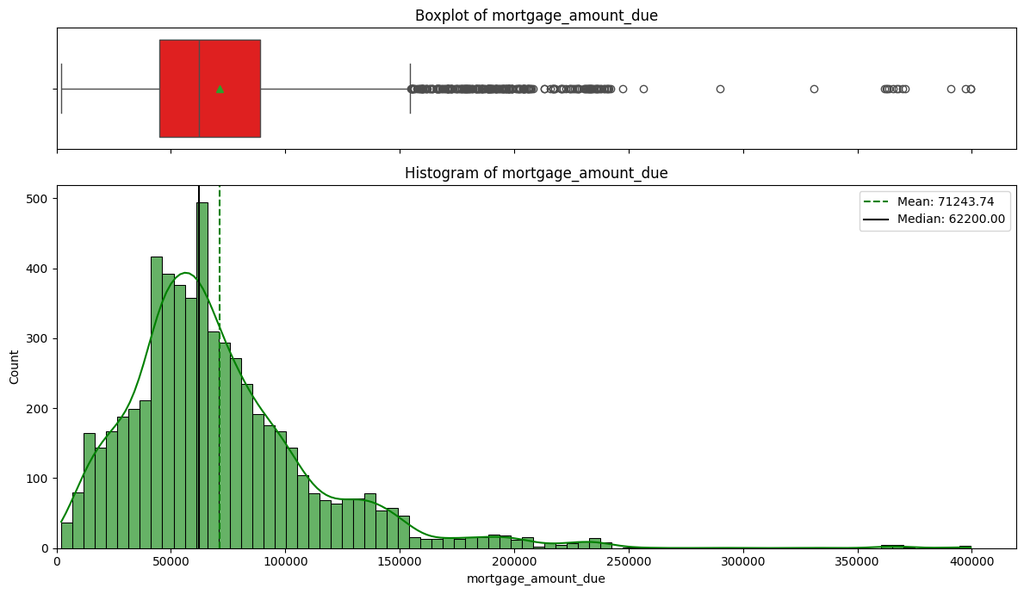

```python
# Plot the numeric variables as histograms and box plots to check skewness and outliers
histogram_boxplot(default_imputed, num_cols[0])
```

#### Observation:

Mortgage amount due shows a slightly right skewed distribution, but with a lot of outliers. These may need to be treated based on the type of modelling technique used for modeling

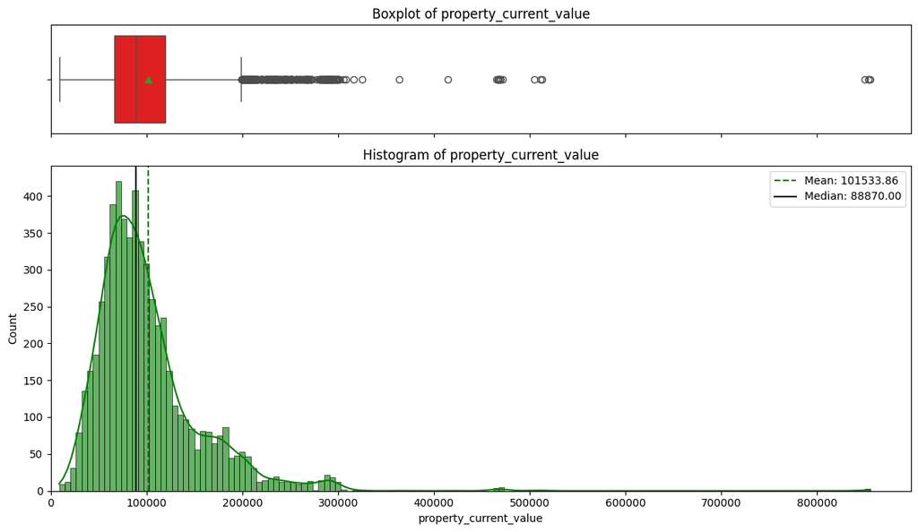

```python
# Plot the numeric variables as histograms and box plots to check skewness and outliers
histogram_boxplot(default_imputed, num_cols[1])
```

#### Observation:

Current property value shows a slightly right skewed distribution, but with a lot of outliers. These may need to be treated based on the type of modelling technique used for modeling

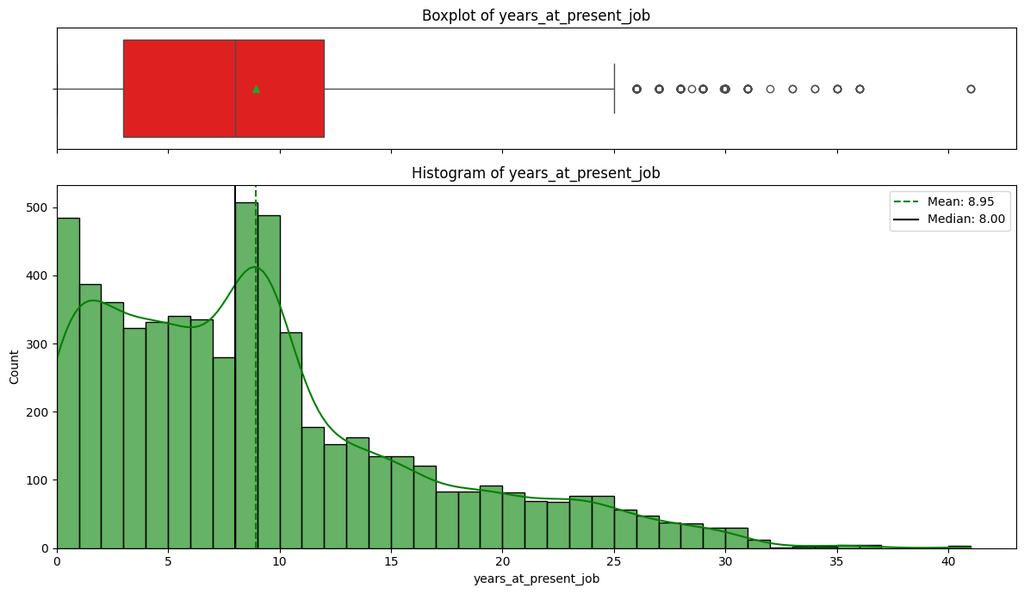

```python
# Plot the numeric variables as histograms and box plots to check skewness and outliers
histogram_boxplot(default_imputed, num_cols[2])
```

#### Observation:

No of years at present job shows a moderately right skewed, multi-modal distribution, with a few outliers, indicating most loan requesters maybe in middle age group. Extreme outliers may have to be capped

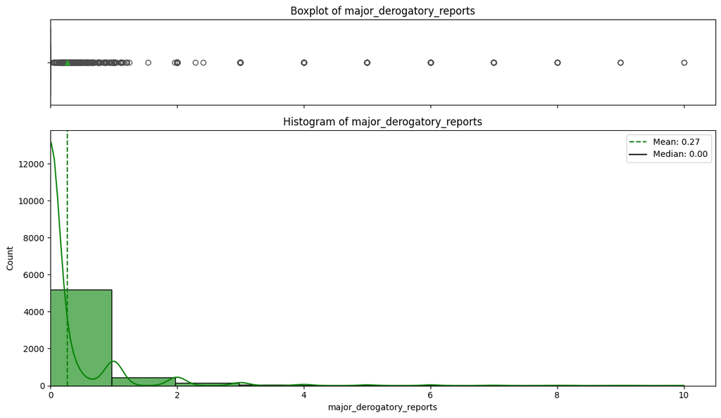

```python
# Plot the numeric variables as histograms and box plots to check skewness and outliers
histogram_boxplot(default_imputed, num_cols[3])
```

#### Observations:

Major derogatory reports shows a highly right skewed distribution, with most values around zero. This may indicate a bias in the prescreening process

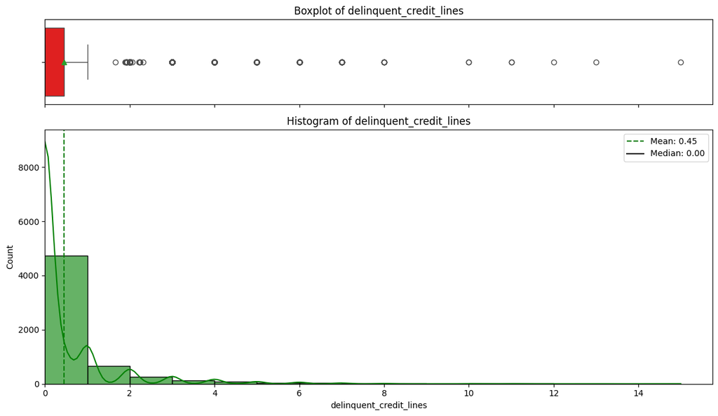

```python
# Plot the numeric variables as histograms and box plots to check skewness and outliers
histogram_boxplot(default_imputed, num_cols[4])
```

#### Observations:

Delinquent credit lines shows a highly right skewed distribution, with most values around zero. This may indicate a bias in the prescreening process

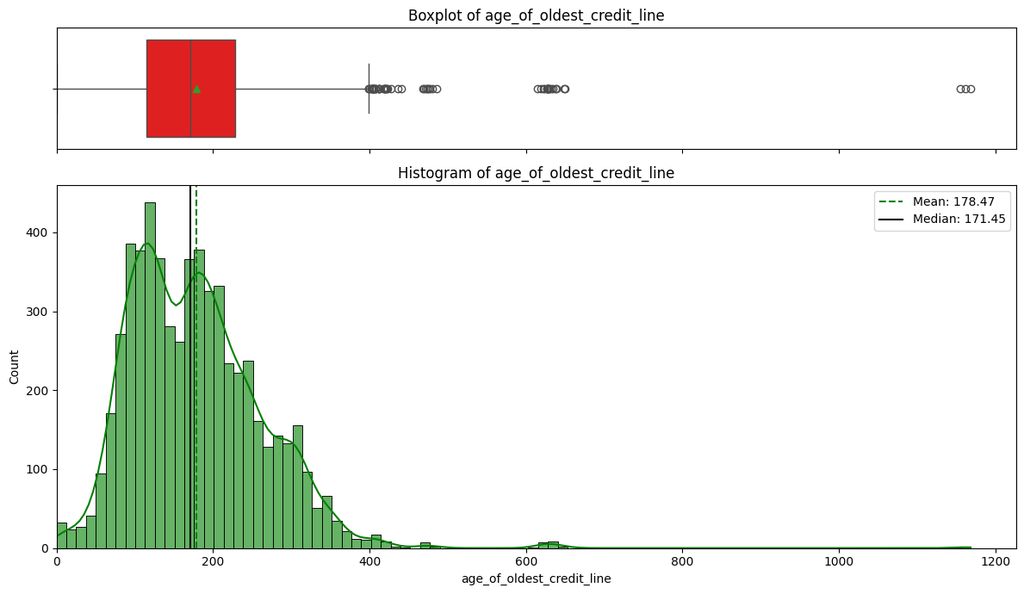

```python
# Plot the numeric variables as histograms and box plots to check skewness and outliers
histogram_boxplot(default_imputed, num_cols[5])
```

#### Observation:

Oldest credit line shows fairly uniform bi-modal distribution, with quite a few outliers. What maybe of interest here are the loan requesters with low or zero age of credit line. Also extreme outliers may have to be capped

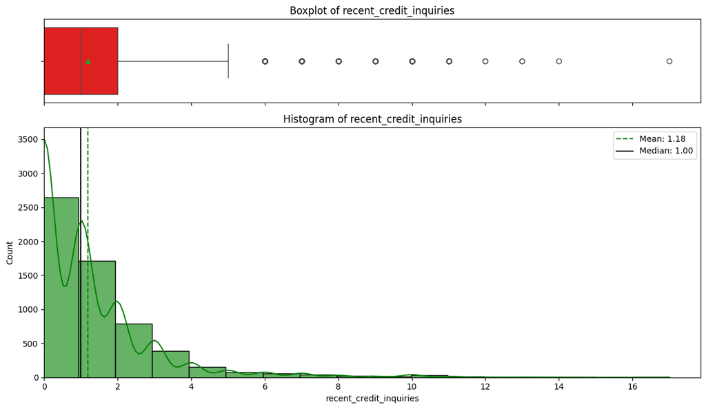

```python
# Plot the numeric variables as histograms and box plots to check skewness and outliers
histogram_boxplot(default_imputed, num_cols[6])
```

#### Observations:

Recent credit inquiries shows a highly right skewed distribution, with most values around zero. This may indicate a bias in the prescreening process

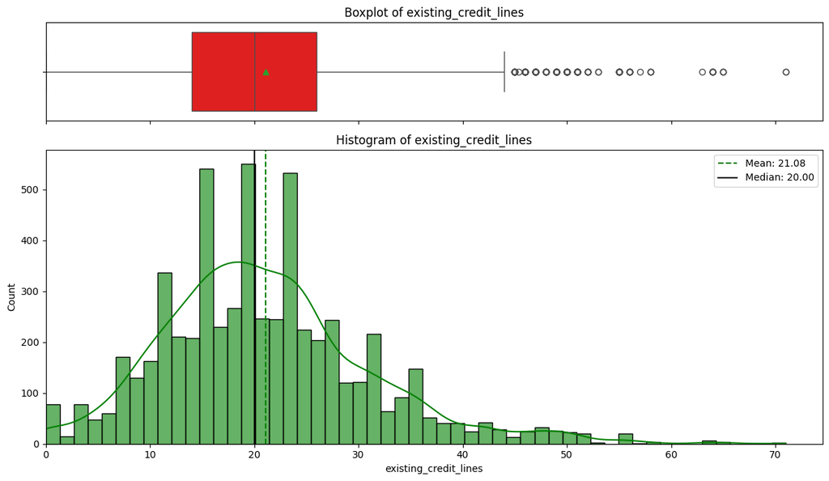

```python
# Plot the numeric variables as histograms and box plots to check skewness and outliers
histogram_boxplot(default_imputed, num_cols[7])
```

#### Observations:

Existing credit lines shows a reasonably uniform distribution with slight right tail and a few outliers. Extreme outliers may need to be capped

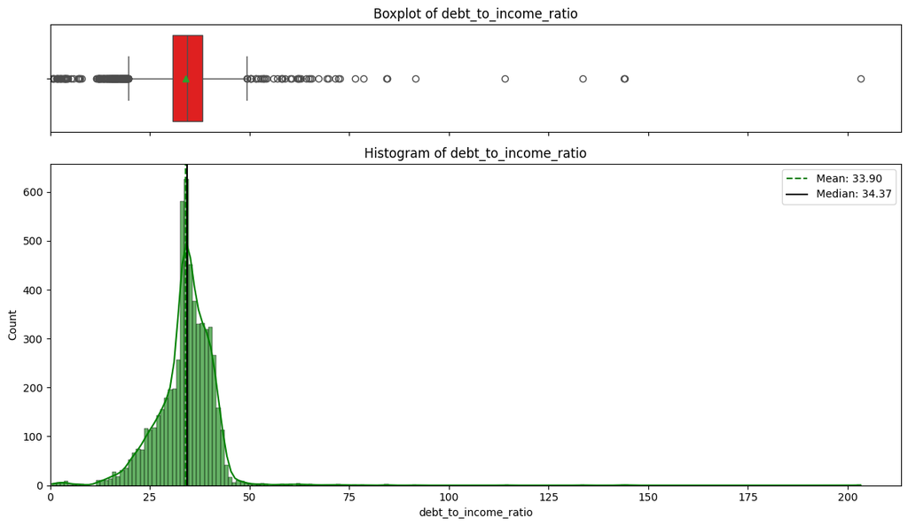

```python
# Plot the numeric variables as histograms and box plots to check skewness and outliers
histogram_boxplot(default_imputed, num_cols[8])
```

#### Observations:

Debt to income ratio is slightly left skewed, with outliers on both sides. Extreme outlier on the high may need capping. Left skewness is a good thing as a low debt to income ratio is desirable The distribution is also showing a sharp drop around ~ 40. Should investigate this further

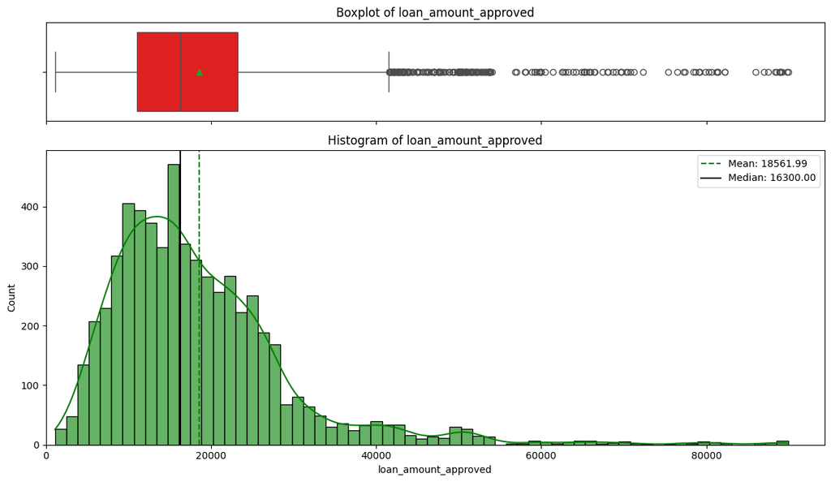

```python
# Plot the numeric variables as histograms and box plots to check skewness and outliers
histogram_boxplot(default_imputed, num_cols[9])
```

#### Observation:

Amount of loan approved shows a slightly right skewed distribution, but with a lot of outliers. These may need to be treated based on the type of modelling technique used for modeling

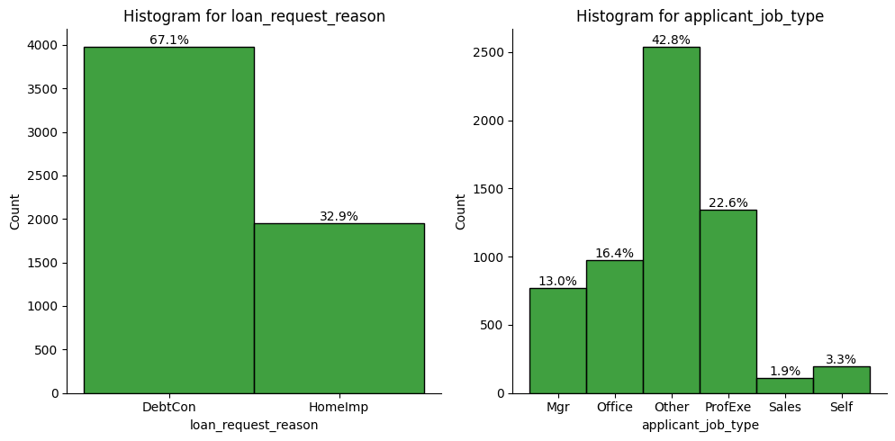

```python
# Plot distribution of categorical columns
plot_categorical_distributions(data=default_imputed, categorical_columns=categorical_columns, cols_per_row=3)
```

#### Observations:

1. ~ 70% of requests are for debt consolidation, indication a fundamental bias in the dataset, or biased selection process
2. Majority (~ 45%) of the loan requests are from people who did not provide details of the profession, suggesting improvements in the data collection process

### Check correlation for numeric variables

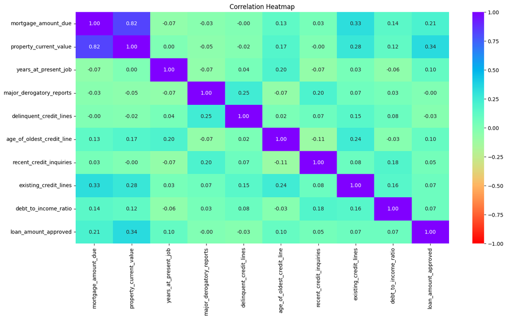

```python
# Calculate the correlation matrix
correlation_matrix = default_imputed[num_cols].corr()
# Plot the heatmap
plt.figure(figsize=(16, 8))  # Adjust figure size if needed
sns.heatmap(correlation_matrix, annot=True, cmap='rainbow_r', fmt=".2f", vmin=-1, vmax=1)
plt.title('Correlation Heatmap')
plt.show()
```

```python
# Sort correlations and exclude duplicates
sorted_unique_correlations = (
    correlation_matrix
    .stack()                            # Flatten the matrix into a Series
    .reset_index()                      # Reset index to access column pairs
    .rename(columns={0: 'correlation'})  # Rename correlation column
    .query("level_0 < level_1")         # Keep only one direction (unique pairs)
    .sort_values(by='correlation', ascending=False)  # Sort by correlation
)
# Print the columns with correlation values
print(sorted_unique_correlations)
```

```
                      level_0                   level_1  correlation
1         mortgage_amount_due    property_current_value     0.823348
91       loan_amount_approved    property_current_value     0.336835
70      existing_credit_lines       mortgage_amount_due     0.326717
71      existing_credit_lines    property_current_value     0.280797
43    delinquent_credit_lines  major_derogatory_reports     0.245317
57  age_of_oldest_credit_line     existing_credit_lines     0.242950
90       loan_amount_approved       mortgage_amount_due     0.210022
36   major_derogatory_reports   recent_credit_inquiries     0.197341
52  age_of_oldest_credit_line      years_at_present_job     0.195221
86       debt_to_income_ratio   recent_credit_inquiries     0.175763
51  age_of_oldest_credit_line    property_current_value     0.171511
87       debt_to_income_ratio     existing_credit_lines     0.162763
47    delinquent_credit_lines     existing_credit_lines     0.152700
80       debt_to_income_ratio       mortgage_amount_due     0.143347
```

[output cut: 31 more lines]

#### Observations:

1. Property value as of date seems to have a strong +ve correlation to mortgage amount due. This is only possible if all if the mortgages in the dataset were approved around the same time and the approved mortgage amount was a fixed % of the property value, irrespective of other factors. So age of the mortgage may be a useful feature (latent variable). Most other variables have weak correlations

#### Let's check the distribution of numerical variables to loan defaults

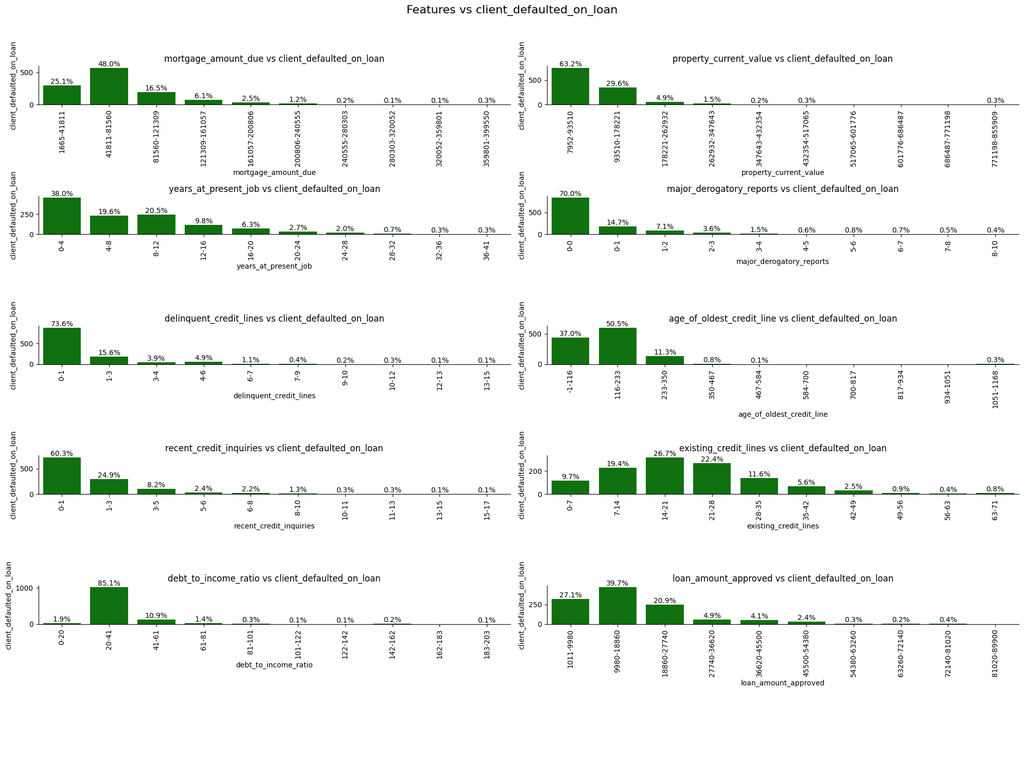

```python
plot_binned_features(default_imputed, num_cols, 'client_defaulted_on_loan', 10)
```

#### Observations

1. No of defaulters are highest where recent credit inquiries, delinquent credit lines, major derogatory reports are the lowest. This seems counter intuitive at first, how ever this is most likely due to these customers not having any credit records at all. This will happen if these customers were denied credit in the past and have not applied for credit in the recent time (for the duration during which this data was collected). Additional data is required to understand this anamoly - gross income, demographics, macroeconomic factors such severe recession or other financial distress
2. Default rate is the extra-ordinarily high (80%) for customers with debt to income ratio between 30-41. Understanding this anomaly likely requires a more detailed analysis of the borrower behavior and external conditions. This data set is insufficient for such analysis, as was commented in no 1 above

#### Let's check the distribution of categorical variables to loan defaults

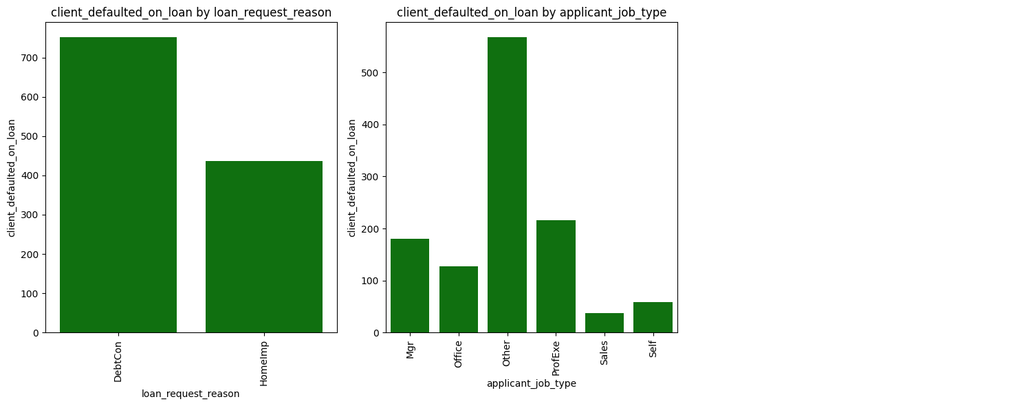

```python
# Plot the categorical variable against the target variable
plot_grouped_barplots(default_imputed, cat_cols, 'client_defaulted_on_loan')
```

#### Observations:

```python
# Perform the Chi-squared test to see if any of the features are not significant to predicting the target variable
print(chi_squared_test(default_imputed, 'client_defaulted_on_loan'))
```

```
                      Feature       P-value  Significant
7     delinquent_credit_lines  3.439216e-76         True
6    major_derogatory_reports  1.917414e-75         True
9     recent_credit_inquiries  7.839235e-32         True
8   age_of_oldest_credit_line  2.204684e-25         True
10      existing_credit_lines  1.385256e-16         True
4          applicant_job_type  5.472220e-16         True
11       debt_to_income_ratio  4.062670e-10         True
0        loan_amount_approved  3.628140e-09         True
2      property_current_value  2.116232e-06         True
5        years_at_present_job  6.555740e-05         True
1         mortgage_amount_due  1.484795e-03         True
3         loan_request_reason  1.991636e-03         True
```

#### Observation:

1. All the available features are significant for the prediction of target variable
2. Also, features related to clients credit posture seem to have higher significance, which is expected

```python
# Calculate correlation matrix and VIF, excluding the target variable
corr_matrix, vif_values = calculate_corr_and_vif(default_imputed, 'client_defaulted_on_loan')

# Display results
print("Correlation Matrix:")

sorted_corr_matrix = corr_matrix[corr_matrix.columns[corr_matrix.iloc[0].argsort()[::-1]]]

sorted_corr_matrix
```

```
Correlation Matrix:
```

|  | loan_amount_approved | property_current_value | mortgage_amount_due | years_at_present_job | age_of_oldest_credit_line | existing_credit_lines | debt_to_income_ratio | recent_credit_inquiries | major_derogatory_reports | delinquent_credit_lines |
| --- | --- | --- | --- | --- | --- | --- | --- | --- | --- | --- |
| loan_amount_approved | 1.000000 | 0.336835 | 0.210022 | 0.103576 | 0.096181 | 0.073079 | 0.070653 | 0.045754 | -0.000074 | -0.028510 |
| mortgage_amount_due | 0.210022 | 0.823348 | 1.000000 | -0.068543 | 0.125605 | 0.326717 | 0.143347 | 0.032090 | -0.032003 | -0.001169 |
| property_current_value | 0.336835 | 1.000000 | 0.823348 | 0.001862 | 0.171511 | 0.280797 | 0.120941 | -0.001928 | -0.049451 | -0.020519 |
| years_at_present_job | 0.103576 | 0.001862 | -0.068543 | 1.000000 | 0.195221 | 0.034446 | -0.060690 | -0.073143 | -0.070228 | 0.038782 |
| major_derogatory_reports | -0.000074 | -0.049451 | -0.032003 | -0.070228 | -0.071447 | 0.069656 | 0.034229 | 0.197341 | 1.000000 | 0.245317 |
| delinquent_credit_lines | -0.028510 | -0.020519 | -0.001169 | 0.038782 | 0.019350 | 0.152700 | 0.083540 | 0.074652 | 0.245317 | 1.000000 |
| age_of_oldest_credit_line | 0.096181 | 0.171511 | 0.125605 | 0.195221 | 1.000000 | 0.242950 | -0.028679 | -0.106623 | -0.071447 | 0.019350 |
| recent_credit_inquiries | 0.045754 | -0.001928 | 0.032090 | -0.073143 | -0.106623 | 0.082074 | 0.175763 | 1.000000 | 0.197341 | 0.074652 |
| existing_credit_lines | 0.073079 | 0.280797 | 0.326717 | 0.034446 | 0.242950 | 1.000000 | 0.162763 | 0.082074 | 0.069656 | 0.152700 |
| debt_to_income_ratio | 0.070653 | 0.120941 | 0.143347 | -0.060690 | -0.028679 | 0.162763 | 1.000000 | 0.175763 | 0.034229 | 0.083540 |

```python
# Print VIF values
print(vif_values)
```

```
                     Feature        VIF
0       loan_amount_approved   4.269935
1        mortgage_amount_due  12.577660
2     property_current_value  14.438231
3       years_at_present_job   2.609784
4   major_derogatory_reports   1.234639
5    delinquent_credit_lines   1.288038
6  age_of_oldest_credit_line   5.570849
7    recent_credit_inquiries   1.647082
8      existing_credit_lines   6.657924
9       debt_to_income_ratio   9.089406
```

#### Observation:

current property value shows a very high correlation with mortgage amount due, which is expected. These should be replaced with an engineered feature. Additional insights can be gained from priniciple component analysis

### **Multivariate Analysis**

#### Multivariate analysis using PCA

#### Prep the data for PCA

```python
# Standardize the data using the dataset with all numeric values from the impute missing values function output (PCA works only with numeric values)
default_imputed_scaled = default_imputed_num.drop('client_defaulted_on_loan', axis=1) # Drop the target variable
 # Scale the data using Z transformation
scaler = StandardScaler()
default_imputed_scaled = pd.DataFrame(scaler.fit_transform(default_imputed_scaled), columns=default_imputed_scaled.columns)
```

```python
# Apply PCA
pca = PCA(n_components=10)  # Reduce to 10 principal components
default_pca = pd.DataFrame(pca.fit_transform(default_imputed_scaled), columns=['PC1', 'PC2', 'PC3', 'PC4', 'PC5', 'PC6', 'PC7', 'PC8', 'PC9', 'PC10'])
```

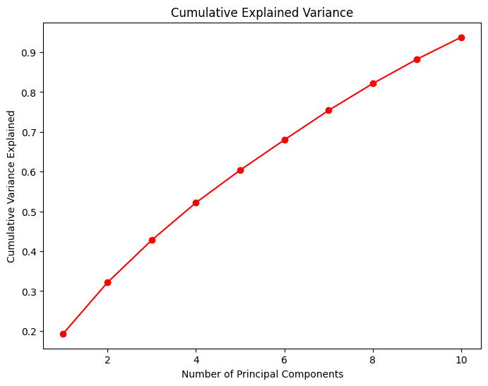

```
PC1: 19.31%
PC2: 12.84%
PC3: 10.63%
PC4: 9.42%
PC5: 8.18%
PC6: 7.61%
PC7: 7.41%
PC8: 6.75%
PC9: 6.12%
PC10: 5.52%
```

```python
# Plot the cumulative variance explained by each principle component for
plot_pca(pca)
# Print explained variance by each component
for i, ratio in enumerate(pca.explained_variance_ratio_, start=1):
    print(f"PC{i}: {ratio:.2%}")
```

#### Observation

There is no single component which can be attributed with a large variance in the dataset

Let's check the contribution of each of the original features to the principle components

```python
# Create a DataFrame to represent the principal component loadings
# Rows are the principal components (PCs), and columns are the original features
loadings = pd.DataFrame(
    pca.components_,  # PCA component weights
    columns=default_imputed_scaled.columns,  # Original feature names
    index=[f'PC{i+1}' for i in range(len(pca.components_))]  # Label PCs as PC1, PC2, etc.
)

# Sort the loadings of the first principal component (PC1) in descending order
# loadings.iloc[0] refers to the first row (PC1), and argsort()[::-1] sorts indices in descending order
sorted_loadings = loadings[loadings.columns[loadings.iloc[0].argsort()[::-1]]]

# Display the sorted loadings
sorted_loadings
```

|  | property_current_value | mortgage_amount_due | existing_credit_lines | loan_amount_approved | age_of_oldest_credit_line | debt_to_income_ratio | applicant_job_type | recent_credit_inquiries | delinquent_credit_lines | years_at_present_job | major_derogatory_reports | loan_request_reason |
| --- | --- | --- | --- | --- | --- | --- | --- | --- | --- | --- | --- | --- |
| PC1 | 0.576112 | 0.564984 | 0.365788 | 0.305518 | 0.218580 | 0.178757 | 0.176315 | 0.053215 | 0.036729 | 0.019602 | -0.012193 | -0.078832 |
| PC2 | -0.093113 | -0.024116 | 0.157196 | -0.032304 | -0.278719 | 0.338654 | -0.160091 | 0.511072 | 0.366841 | -0.251812 | 0.483022 | -0.233470 |
| PC3 | -0.132263 | -0.162364 | 0.305187 | -0.092110 | 0.483609 | -0.051080 | -0.069939 | -0.083843 | 0.493531 | 0.488090 | 0.243976 | 0.254524 |
| PC4 | 0.098927 | 0.163554 | 0.003535 | -0.436486 | -0.111430 | -0.049082 | 0.415361 | -0.139306 | 0.157561 | -0.417550 | 0.192387 | 0.574446 |
| PC5 | -0.032727 | 0.052813 | 0.257030 | -0.460685 | 0.129790 | 0.534424 | -0.433102 | -0.043678 | -0.109916 | -0.109107 | -0.435882 | 0.109201 |
| PC6 | 0.085399 | -0.026710 | -0.384590 | 0.295329 | -0.176204 | 0.454081 | 0.004328 | 0.250325 | -0.077816 | 0.360811 | -0.002498 | 0.566304 |
| PC7 | -0.284060 | -0.262775 | 0.221210 | -0.032446 | 0.225009 | 0.265317 | 0.701409 | 0.301882 | -0.225197 | 0.027548 | -0.164132 | -0.133160 |
| PC8 | 0.069075 | 0.083879 | 0.067089 | -0.188289 | 0.285217 | -0.379258 | -0.232844 | 0.568766 | -0.502117 | -0.001529 | 0.218310 | 0.213448 |
| PC9 | 0.106624 | 0.194785 | 0.085709 | -0.407826 | -0.477220 | -0.239403 | 0.141333 | 0.275006 | 0.183974 | 0.505097 | -0.307595 | -0.113060 |
| PC10 | -0.002660 | 0.036289 | 0.216231 | -0.190367 | -0.256801 | 0.218407 | 0.039390 | -0.392728 | -0.484286 | 0.336688 | 0.534570 | -0.112197 |

#### Create a new feature to replace Mortgage due and property value as they are highly correlated, and check if it impacts the PCs

```python
default_imputed_scaled_eng = engineer_and_scale_features(
    data=default_imputed_scaled,
    ratio_cols=('mortgage_amount_due', 'property_current_value'),
    new_feature_name='ltv',
    drop_original=True
)
```

```python
# Apply PCA
pca_nopv = PCA(n_components=10)  # First 10 PCs
default_pcanopv = pd.DataFrame(pca_nopv.fit_transform(default_imputed_scaled_eng), columns=['PCe1', 'PCe2', 'PCe3', 'PCe4', 'PCe5', 'PCe6', 'PCe7', 'PCe8', 'PCe9', 'PCe10'])
```

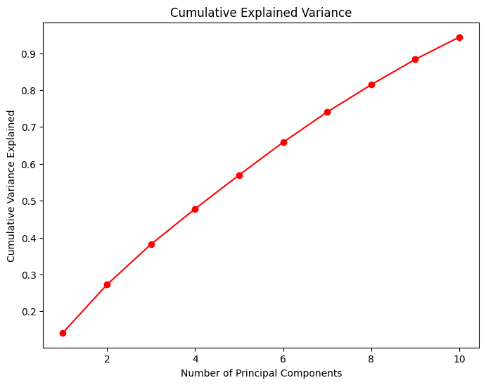

```
PCe1: 14.21%
PCe2: 13.05%
PCe3: 10.93%
PCe4: 9.61%
PCe5: 9.17%
PCe6: 8.88%
PCe7: 8.19%
PCe8: 7.42%
PCe9: 6.88%
PCe10: 6.02%
```

```python
# Plot explained variance ratio
plot_pca(pca_nopv)

# Print explained variance by each component
for i, ratio in enumerate(pca_nopv.explained_variance_ratio_, start=1):
    print(f"PCe{i}: {ratio:.2%}")
```

```python
loadings_noPV = pd.DataFrame(pca_nopv.components_, columns=default_imputed_scaled_eng.columns, index=[f'PCe{i+1}' for i in range(len(pca_nopv.components_))])
sorted_loadings_noPV = loadings_noPV[loadings_noPV.columns[loadings_noPV.iloc[0].argsort()[::-1]]]
sorted_loadings_noPV
```

|  | recent_credit_inquiries | major_derogatory_reports | debt_to_income_ratio | delinquent_credit_lines | existing_credit_lines | loan_amount_approved | ltv | age_of_oldest_credit_line | applicant_job_type | years_at_present_job | loan_request_reason |
| --- | --- | --- | --- | --- | --- | --- | --- | --- | --- | --- | --- |
| PCe1 | 0.483021 | 0.437931 | 0.403157 | 0.396194 | 0.381547 | 0.154054 | -0.002213 | -0.041971 | -0.051839 | -0.119536 | -0.259518 |
| PCe2 | -0.185975 | -0.158836 | 0.027133 | 0.068006 | 0.440729 | 0.328600 | -0.054357 | 0.625871 | 0.208210 | 0.440109 | 0.029765 |
| PCe3 | -0.141348 | 0.359382 | -0.163761 | 0.500103 | 0.038205 | -0.472916 | 0.081498 | 0.128777 | -0.031688 | 0.121913 | 0.556546 |
| PCe4 | -0.034753 | -0.031385 | 0.145670 | -0.128218 | 0.193107 | -0.084681 | 0.116205 | -0.007708 | 0.774984 | -0.501743 | 0.223106 |
| PCe5 | -0.093918 | -0.125821 | 0.005852 | -0.002576 | 0.160512 | -0.129036 | 0.931971 | 0.025127 | -0.137553 | 0.009290 | -0.211389 |
| PCe6 | -0.003477 | -0.423846 | 0.594608 | -0.128046 | 0.222273 | -0.418444 | -0.169025 | 0.124122 | -0.359620 | -0.121863 | 0.194257 |
| PCe7 | 0.263959 | -0.010993 | 0.430953 | -0.088308 | -0.351397 | 0.309891 | 0.255045 | -0.177457 | 0.121063 | 0.408692 | 0.488824 |
| PCe8 | 0.656068 | 0.134641 | -0.317828 | -0.503714 | 0.114697 | -0.272325 | 0.039374 | 0.295856 | -0.016963 | 0.096905 | 0.103097 |
| PCe9 | 0.202133 | -0.348997 | -0.035993 | 0.243467 | 0.059042 | -0.418077 | -0.100395 | -0.337446 | 0.391011 | 0.480007 | -0.302079 |
| PCe10 | -0.401370 | 0.545022 | 0.252952 | -0.477929 | 0.179816 | -0.207754 | -0.051600 | -0.202716 | 0.066854 | 0.320879 | -0.150890 |

#### Observations

Based on PCA analysis, it is clear that replacing 'mortgage_amount_due', 'property_current_value' by 'mortgage_to_property_ratio' will not impact modelling performance

## Treating Outliers

Only the outliers for mortgage due and property value have been dropped, where the ratio of these features was improbable. See section to 1.4.0.1. All the other outliers are maintained as is as they seem to be realistic data points

## Treating Missing Values: See section 1.6.1.1

## **Important Insights from EDA**

### Key Data Insights for Classification

#### Handling Missing Values

- Critical features like `loan_request_reason` and `property_current_value` must have no missing values as they are essential for predicting loan defaults.
- Features like `major_derogatory_reports` and `debt_to_income_ratio` (with missing rates of 11.9% and 21.3%) require imputation or exclusion based on their impact.

#### Potential Predictors

- Features such as `debt_to_income_ratio`, `major_derogatory_reports`, `recent_credit_inquiries`, and `existing_credit_lines` are likely predictive but require normalization and outlier treatment.

#### Feature Engineering

- Replace correlated variables (`mortgage_amount_due` and `property_current_value`) with `mortgage_to_property_ratio`.
- Consider creating latent features such as "age of mortgage" or "credit history duration" for added predictive power.

#### Skewness and Outliers

- Many numerical features (e.g., `debt_to_income_ratio`, `mortgage_amount_due`) are right-skewed with significant outliers.
- Apply transformations and outlier capping to improve model robustness.

#### Bias and Feature Validity

- Categorical variables like `applicant_job_type` and `loan_request_reason` show inherent bias (e.g., 70% of loans are for debt consolidation).
- Features like `job_type` and `years_at_present_job` may raise ethical or legal concerns.

#### Class Separation and Patterns

- Default rates are high for clients with minimal credit records or specific debt-to-income ranges (30–41%).
- This highlights actionable risk segments.

### Key Statistical Insights

#### Correlations

- Strong correlation between `property_current_value` and `mortgage_amount_due` supports dimensionality reduction.
- Weak correlations across most features suggest the need for engineered features or interaction terms.

### Recommendations for Modeling

#### Preprocessing

- Treat missing values based on correlation and domain importance.
- Normalize or transform skewed features and cap outliers.
- Create engineered features (e.g., `mortgage_to_property_ratio`).

#### Bias Mitigation

- Address potential dataset bias (e.g., over-representation of debt consolidation loans).
- Carefully handle legally sensitive features like `job_type` to avoid bias in classification.

#### Feature Selection

- Prioritize credit-related features (`debt_to_income_ratio`, `recent_credit_inquiries`, `delinquent_credit_lines`) given their significance for predicting defaults.

#### Advanced Analysis

- Investigate latent variables and external data (e.g., economic conditions) to explain observed anomalies in defaults.

## **Model Building - Approach**

- Data preparation
- Partition the data into train and test set
- Build the model
- Fit on the train data
- Tune the model
- Test the model on test set

```python
# Create a dataframe for modeling from original imputed dataframe
default_model = copy.deepcopy(default_imputed)
default_model['ltv'] = default_model['mortgage_amount_due']/default_model['property_current_value']  # Create the new ltv feature
```

```python
default_model.drop(columns=['mortgage_amount_due', 'property_current_value'], inplace=True)  # Drop the original feature used to create ltv
```

```python
default_model = engineer_and_scale_features(
    data=default_imputed,
    ratio_cols=('mortgage_amount_due', 'property_current_value'),
    new_feature_name='ltv',
    drop_original=True
)
```

```python
# Transform the categorical variables using one-hot encoding
default_model = pd.get_dummies(default_model, columns=['loan_request_reason', 'applicant_job_type'])
```

```python
# Separate the target variable
Y = default_model.client_defaulted_on_loan
X = default_model.drop('client_defaulted_on_loan', axis=1)
```

```python
Y.value_counts()
```

```
client_defaulted_on_loan
0    4747
1    1188
Name: count, dtype: int64
```

```python
# Scale the data
sc = StandardScaler()
X_scaled = sc.fit_transform(X)
X_scaled = pd.DataFrame(X_scaled, columns = X.columns)
```

```python
# Create the training anb testing datasets
x_train, x_test, y_train, y_test = train_test_split(X_scaled, Y, test_size = 0.3, random_state = 1, stratify = Y)
# Reset index of test set for alignment
x_test = x_test.reset_index(drop=True)
y_test = y_test.reset_index(drop=True)
```

```python
# Define scoring metrics to be optimized during GridSearch
optimum = ['accuracy', 'f1', 'recall', 'precision']
```

#### Confusion Matrix

| Actual/Predicted | Predicted: 0 (No Default) | Predicted: 1 (Default) |
| --- | --- | --- |
| Actual: 0 (No Default) | True Negative (TN) | False Positive (FP) |
| Actual: 1 (Default) | False Negative (FN) | True Positive (TP) |

Classification model should maximize the expected value of the revenue from lending. In order to acheive this:

1. Maximize True Negatives - This will bring in the bulk of the interest revenue
2. Minimize False Negatives - This will reduce the interest loss due to defaulted loans (principle can be recouped via foreclosure)
3. Minimize False Positives - This will minimize the opportunity loss

To achieve this, we will define 2 functions

### Function to calculate the expected revenue:

$ \text{Expected Revenue} = \text{Revenue from True Negatives (TN)} - \text{Loss from False Positives (FP)} - \text{Loss from False Negatives (FN)} $

1. Revenue from True Negatives (TN):

$ \text{Revenue}{\text{TN}} = P{\text{ND}} \cdot (1 - \text{Actual}) \cdot L \cdot r $ Where: • $P_{\text{ND}} = 1 - P_{\text{D}}$: Probability of non-default. • $\text{Actual}$: Indicator of the actual outcome ($0$ = non-default, $1$ = default). • $L$: Loan amount. • $r$: Interest rate.

2. Loss from False Positives (FP):

$ \text{Loss}{\text{FP}} = P{\text{D}} \cdot (1 - \text{Actual}) \cdot L \cdot r $ Where: • $P_{\text{D}}$: Probability of default. • $(1 - \text{Actual})$: Ensures the outcome is non-default ($\text{Actual} = 0$). • $L \cdot r$: Opportunity cost (lost interest revenue).

3. Loss from False Negatives (FN):

$ \text{Loss}{\text{FN}} = P{\text{ND}} \cdot \text{Actual} \cdot L \cdot (1 + r) $ Where: • $P_{\text{ND}}$: Probability of non-default. • $\text{Actual}$: Ensures the outcome is default ($\text{Actual} = 1$). • $L \cdot (1 + r)$: Total loss (principal + interest).

Definitions: • $P_{\text{D}}$: Probability of default. • $P_{\text{ND}} = 1 - P_{\text{D}}$: Probability of non-default. • $\text{Actual}$: Binary variable ($0 = \text{Non-default}, 1 = \text{Default}$). • $L$: Loan amount. • $r$: Interest rate.

```python
model_metrics = pd.DataFrame(columns = ['Model Name', 'Model Type', 'Grid Search (Yes/No)', 'Recall', 'Precision', 'f1', 'Accuracy', 'FPs', 'FNs', 'Revenue Prediction', 'Confidence'])
model_metrics
```

|  | Model Name | Model Type | Grid Search (Yes/No) | Recall | Precision | f1 | Accuracy | FPs | FNs | Revenue Prediction | Confidence |
| --- | --- | --- | --- | --- | --- | --- | --- | --- | --- | --- | --- |

### Logistic Regression

```python
# Fit logistic regression model to training data with default parameters except solver = liblinear, since liblinear solver is optimized for linear problems with small datasets and binary classification
lg = LogisticRegression(verbose=1, solver='liblinear', random_state=1)
lg.fit(x_train, y_train)
```

```
[LibLinear]iter  1 act 1.129e+03 pre 1.027e+03 delta 1.507e+00 f 2.879e+03 |g| 1.543e+03 CG   2
iter  2 act 8.510e+01 pre 7.440e+01 delta 1.507e+00 f 1.750e+03 |g| 3.049e+02 CG   2
iter  3 act 6.884e+00 pre 6.498e+00 delta 1.507e+00 f 1.665e+03 |g| 6.961e+01 CG   3
iter  4 act 6.872e-02 pre 6.826e-02 delta 1.507e+00 f 1.658e+03 |g| 6.357e+00 CG   2
iter  5 act 1.542e-04 pre 1.542e-04 delta 1.507e+00 f 1.658e+03 |g| 4.511e-01 CG   3
```

```
LogisticRegression(random_state=1, solver='liblinear', verbose=1)
```

```
              precision    recall  f1-score   support

           0       0.84      0.97      0.90      3323
           1       0.70      0.29      0.41       831

    accuracy                           0.83      4154
   macro avg       0.77      0.63      0.65      4154
weighted avg       0.82      0.83      0.80      4154
```

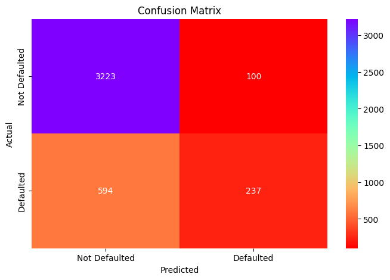

```python
# Check the performance on the training data
y_pred_train = lg.predict(x_train)
metrics_score(y_train, y_pred_train)
```

```python
# Checking the performance on the test data
lg_metric_dict = evaluate_model_and_metrics(lg, x_test, y_test, X_scaled, default_model, 'lg', 'Logistic Regression')
```

```
              precision    recall  f1-score   support

           0       0.84      0.98      0.91      1424
           1       0.75      0.27      0.40       357

    accuracy                           0.84      1781
   macro avg       0.80      0.63      0.65      1781
weighted avg       0.82      0.84      0.80      1781
```

```
Total expected revenue: 2698670.8381685987 with confidence of: 0.8378248172411434
```

```python
model_metrics.loc[len(model_metrics)] = lg_metric_dict
```

#### Check which features are driving the predictions

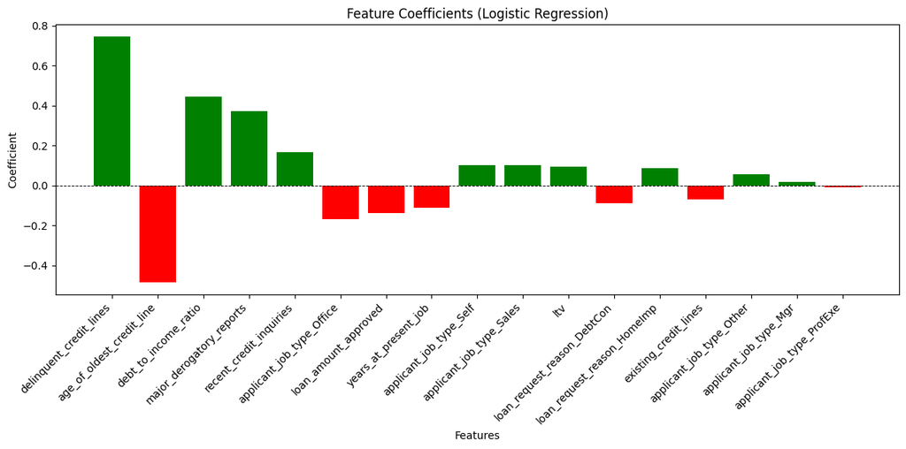

```python
plot_feature_importances_or_coefficients(lg, X, 'logistic_regression')
```

#### Check the features/values driving the False Negatives

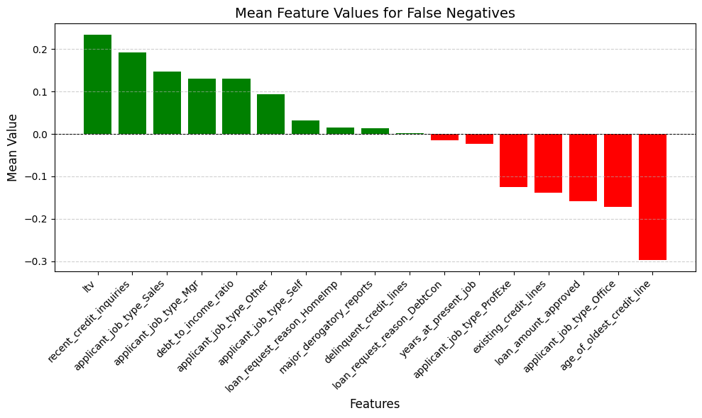

```python
analyze_subset_features(
    model=lg,
    x_test=x_test,
    y_test=y_test,
    subset='false_negatives'
)
```

### Observation

The performance of the model on the trained data and test data is almost identical.  
Primary driving factors are related to the -ve credit history of the client and the income.  
Loan amount approved and existing credit lines has a negative coefficient.\

Most of the False Negatives are due to more imporant feature(s) having mean near zero.  
We will check if this a pattern across different models.\

Overall the performance of Logistic regression is not satisfactory as the recall is very low.

**Let's see if we can improve the performance by gridsearch**

```
Optimizing for: accuracy
Fitting 5 folds for each of 240 candidates, totalling 1200 fits
Best Parameters for accuracy: {'C': 0.1, 'max_iter': 500, 'penalty': 'l2', 'solver': 'saga'}
Best Cross-Validation Score for accuracy: 0.8348605976251576
              precision    recall  f1-score   support

           0       0.84      0.98      0.91      1424
           1       0.76      0.27      0.40       357

    accuracy                           0.84      1781
   macro avg       0.80      0.63      0.65      1781
weighted avg       0.83      0.84      0.81      1781
```

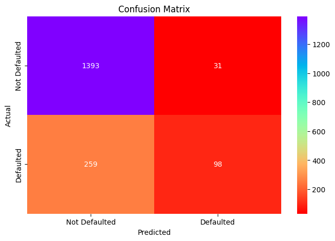

```
Total expected revenue: 2668632.2538089366 with confidence of: 0.8371075503756462
Optimizing for: f1
Fitting 5 folds for each of 240 candidates, totalling 1200 fits
Best Parameters for f1: {'C': 1, 'max_iter': 500, 'penalty': 'l1', 'solver': 'liblinear'}
Best Cross-Validation Score for f1: 0.41319388831189974
              precision    recall  f1-score   support

           0       0.84      0.98      0.91      1424
           1       0.75      0.27      0.40       357

    accuracy                           0.84      1781
   macro avg       0.80      0.63      0.65      1781
weighted avg       0.82      0.84      0.80      1781
```

```
Total expected revenue: 2694612.6500502788 with confidence of: 0.8378092652169723
Optimizing for: recall
Fitting 5 folds for each of 240 candidates, totalling 1200 fits
Best Parameters for recall: {'C': 1, 'max_iter': 500, 'penalty': 'l1', 'solver': 'liblinear'}
Best Cross-Validation Score for recall: 0.29241036000288584
              precision    recall  f1-score   support

           0       0.84      0.98      0.91      1424
           1       0.75      0.27      0.40       357

    accuracy                           0.84      1781
   macro avg       0.80      0.63      0.65      1781
weighted avg       0.82      0.84      0.80      1781
```

```
Total expected revenue: 2694612.6500502788 with confidence of: 0.8378092652169723
Optimizing for: precision
Fitting 5 folds for each of 240 candidates, totalling 1200 fits
Best Parameters for precision: {'C': 0.01, 'max_iter': 500, 'penalty': 'l1', 'solver': 'saga'}
Best Cross-Validation Score for precision: 0.8168677410782674
              precision    recall  f1-score   support

           0       0.83      0.99      0.90      1424
           1       0.78      0.18      0.30       357

    accuracy                           0.83      1781
   macro avg       0.81      0.58      0.60      1781
weighted avg       0.82      0.83      0.78      1781
```

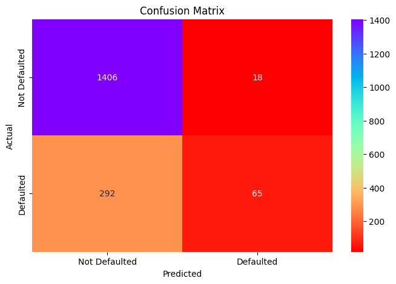

```
Total expected revenue: 1760434.3874773076 with confidence of: 0.8193714654977431
```

```python
# Define the model
log_reg = LogisticRegression(solver='liblinear', random_state=1)

# Define the parameter grid to search over
param_grid = {
    'penalty': ['l1', 'l2', 'elasticnet', 'none'],  # Regularization techniques
    'C': [0.01, 0.1, 1, 10, 100],  # Regularization strength
    'solver': ['lbfgs', 'liblinear', 'saga'],  # Solvers compatible with l1 and elasticnet penalties
    'max_iter': [500, 1000, 2000, 3000]  # Number of iterations for convergence
}

results = {}  # Dictionary to store all results dynamically

# Perform GridSearchCV for each scoring metric
for opt in optimum:
    print(f"Optimizing for: {opt}")

    # Set up GridSearchCV
    grid_search = GridSearchCV(
        estimator=log_reg,
        param_grid=param_grid,
        scoring=opt,
        cv=5,
        verbose=1,
        n_jobs=-1
    )

    # Perform the grid search on the training data
    grid_search.fit(x_train, y_train)

    # Store best parameters and cross-validation score
    results[opt] = {
        'best_params': grid_search.best_params_,
        'best_score': grid_search.best_score_,
        'best_model': grid_search.best_estimator_
    }

    print(f"Best Parameters for {opt}: {results[opt]['best_params']}")
    print(f"Best Cross-Validation Score for {opt}: {results[opt]['best_score']}")

    # Evaluate the best model and append results
    model_metrics.loc[len(model_metrics)] = evaluate_model_and_metrics(results[opt]['best_model'], x_test, y_test, X_scaled, default_model, f'log_reg_{opt}', 'Logistic Regression', grid_search=True)
```

### Decision Tree

```python
# Building decision tree model
dt = DecisionTreeClassifier(criterion='entropy', random_state=1)
```

```python
# Fitting decision tree model
dt.fit(x_train, y_train)
```

```
DecisionTreeClassifier(criterion='entropy', random_state=1)
```

```
              precision    recall  f1-score   support

           0       0.84      0.97      0.90      3323
           1       0.70      0.29      0.41       831

    accuracy                           0.83      4154
   macro avg       0.77      0.63      0.65      4154
weighted avg       0.82      0.83      0.80      4154
```

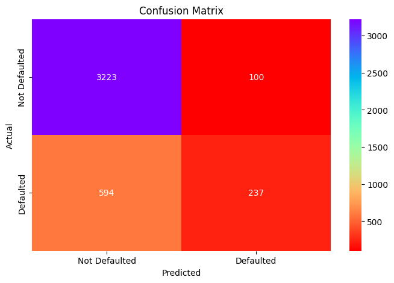

```python
# Check the performance on the training data
y_pred_train = lg.predict(x_train)
metrics_score(y_train, y_pred_train)
```

```
              precision    recall  f1-score   support

           0       0.90      0.93      0.91      1424
           1       0.68      0.57      0.62       357

    accuracy                           0.86      1781
   macro avg       0.79      0.75      0.76      1781
weighted avg       0.85      0.86      0.85      1781
```

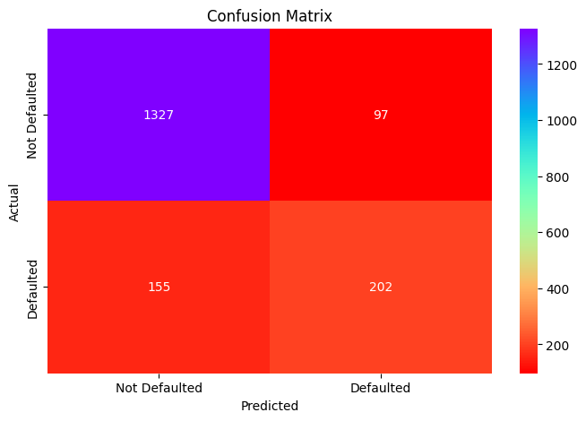

```
Total expected revenue: 7501717.5 with confidence of: 1.0
```

```python
# Checking the performance on the test data
model_metrics.loc[len(model_metrics)] = evaluate_model_and_metrics(dt, x_test, y_test, X_scaled, default_model, 'dt', 'Decision Tree')
```

```python
model_metrics
```

|  | Model Name | Model Type | Grid Search (Yes/No) | Recall | Precision | f1 | Accuracy | FPs | FNs | Revenue Prediction | Confidence |
| --- | --- | --- | --- | --- | --- | --- | --- | --- | --- | --- | --- |
| 0 | lg | Logistic Regression | No | 0.274510 | 0.748092 | 0.401639 | 0.836047 | 33 | 259 | 2.698671e+06 | 0.837825 |
| 1 | log_reg_accuracy | Logistic Regression | Yes | 0.274510 | 0.759690 | 0.403292 | 0.837170 | 31 | 259 | 2.668632e+06 | 0.837108 |
| 2 | log_reg_f1 | Logistic Regression | Yes | 0.274510 | 0.748092 | 0.401639 | 0.836047 | 33 | 259 | 2.694613e+06 | 0.837809 |
| 3 | log_reg_recall | Logistic Regression | Yes | 0.274510 | 0.748092 | 0.401639 | 0.836047 | 33 | 259 | 2.694613e+06 | 0.837809 |
| 4 | log_reg_precision | Logistic Regression | Yes | 0.182073 | 0.783133 | 0.295455 | 0.825940 | 18 | 292 | 1.760434e+06 | 0.819371 |
| 5 | dt | Decision Tree | No | 0.565826 | 0.675585 | 0.615854 | 0.858506 | 97 | 155 | 7.501718e+06 | 1.000000 |

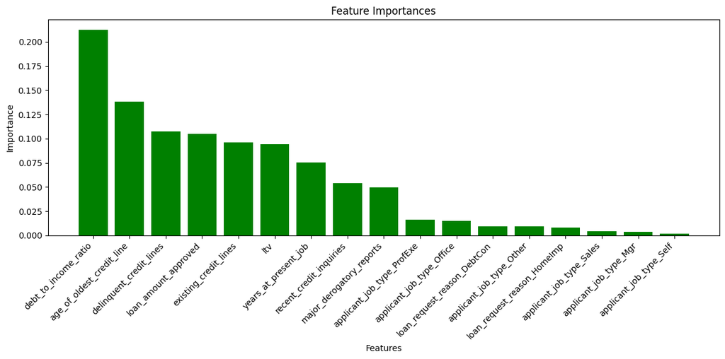

```python
plot_feature_importances_or_coefficients(dt, X)
```

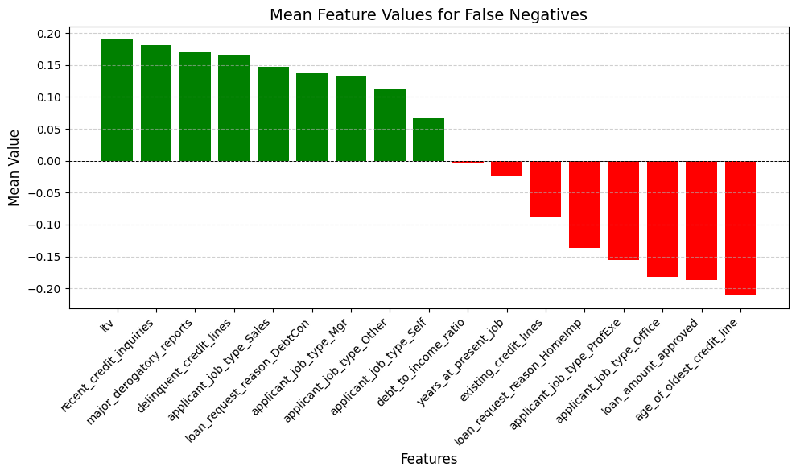

```python
analyze_subset_features(
    model=dt,
    x_test=x_test,
    y_test=y_test,
    subset='false_negatives'
)
```

### **Decision Tree - Hyperparameter Tuning**

- Hyperparameter tuning is tricky in the sense that **there is no direct way to calculate how a change in the hyperparameter value will reduce the loss of your model**, so we usually resort to experimentation. We'll use Grid search to perform hyperparameter tuning.
- **Grid search is a tuning technique that attempts to compute the optimum values of hyperparameters.**
- **It is an exhaustive search** that is performed on the specific parameter values of a model.
- The parameters of the estimator/model used to apply these methods are **optimized by cross-validated grid-search** over a parameter grid.

**Criterion {“gini”, “entropy”}**

The function to measure the quality of a split. Supported criteria are “gini” for the Gini impurity and “entropy” for the information gain.

**max_depth**

The maximum depth of the tree. If None, then nodes are expanded until all leaves are pure or until all leaves contain less than min_samples_split samples.

**min_samples_leaf**

The minimum number of samples is required to be at a leaf node. A split point at any depth will only be considered if it leaves at least min_samples_leaf training samples in each of the left and right branches. This may have the effect of smoothing the model, especially in regression.

You can learn about more Hyperpapameters on this link and try to tune them.

https://scikit-learn.org/stable/modules/generated/sklearn.tree.DecisionTreeClassifier.html

```
Optimizing for: accuracy
Fitting 5 folds for each of 162 candidates, totalling 810 fits
Best Parameters for accuracy: {'criterion': 'entropy', 'max_depth': 20, 'max_features': 'sqrt', 'min_samples_leaf': 1, 'min_samples_split': 2}
Best Cross-Validation Score for accuracy: 0.8690417989648122
              precision    recall  f1-score   support

           0       0.90      0.93      0.91      1424
           1       0.67      0.59      0.63       357

    accuracy                           0.86      1781
   macro avg       0.79      0.76      0.77      1781
weighted avg       0.86      0.86      0.86      1781
```

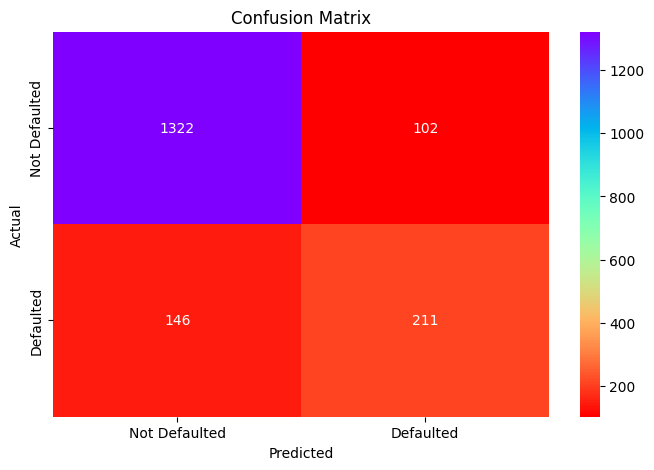

```
Total expected revenue: 7346832.213055555 with confidence of: 0.9957231114855378
Optimizing for: f1
Fitting 5 folds for each of 162 candidates, totalling 810 fits
Best Parameters for f1: {'criterion': 'entropy', 'max_depth': 20, 'max_features': 'sqrt', 'min_samples_leaf': 1, 'min_samples_split': 2}
Best Cross-Validation Score for f1: 0.6471139599990672
              precision    recall  f1-score   support

           0       0.90      0.93      0.91      1424
           1       0.67      0.59      0.63       357

    accuracy                           0.86      1781
   macro avg       0.79      0.76      0.77      1781
weighted avg       0.86      0.86      0.86      1781
```

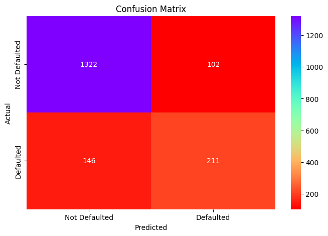

```
Total expected revenue: 7346832.213055555 with confidence of: 0.9957231114855378
Optimizing for: recall
Fitting 5 folds for each of 162 candidates, totalling 810 fits
Best Parameters for recall: {'criterion': 'entropy', 'max_depth': None, 'max_features': 0.5, 'min_samples_leaf': 1, 'min_samples_split': 2}
Best Cross-Validation Score for recall: 0.6053026477166149
              precision    recall  f1-score   support

           0       0.89      0.92      0.90      1424
           1       0.63      0.57      0.60       357

    accuracy                           0.85      1781
   macro avg       0.76      0.74      0.75      1781
weighted avg       0.84      0.85      0.84      1781
```

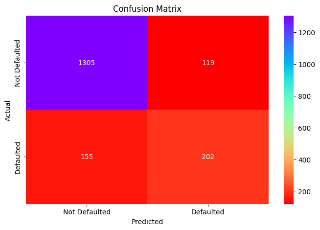

```
Total expected revenue: 7458707.5 with confidence of: 1.0
Optimizing for: precision
Fitting 5 folds for each of 162 candidates, totalling 810 fits
Best Parameters for precision: {'criterion': 'gini', 'max_depth': 10, 'max_features': 0.5, 'min_samples_leaf': 2, 'min_samples_split': 10}
Best Cross-Validation Score for precision: 0.7650397476463924
              precision    recall  f1-score   support

           0       0.88      0.97      0.92      1424
           1       0.80      0.46      0.58       357

    accuracy                           0.87      1781
   macro avg       0.84      0.72      0.75      1781
weighted avg       0.86      0.87      0.85      1781
```

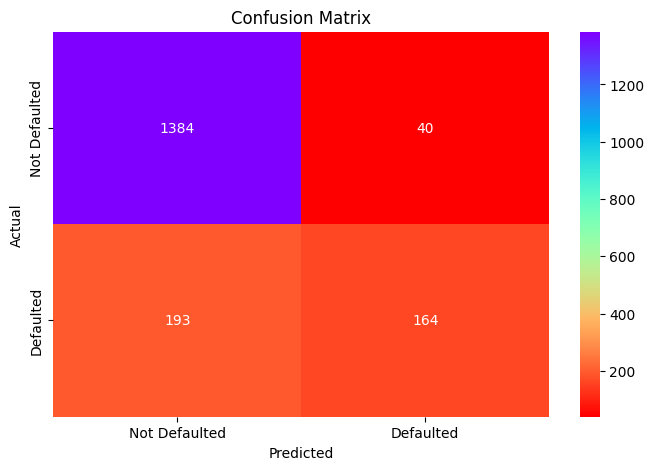

```
Total expected revenue: 4874592.316435514 with confidence of: 0.9113513355931812
```

```python
# Define the Decision Tree model
dtree_estimator_grid = DecisionTreeClassifier(random_state=1)

# Define the parameter grid to search over
parameters = {
    'max_depth': [10, 20, None],
    'min_samples_split': [2, 5, 10],
    'min_samples_leaf': [1, 2, 5],
    'max_features': ['sqrt', 'log2', 0.5],
    'criterion': ['gini', 'entropy']
}

# Initialize results dictionary and DataFrame
results = {}

# Perform GridSearchCV for each scoring metric
for opt in optimum:
    print(f"Optimizing for: {opt}")

    # Set up GridSearchCV
    grid_search = GridSearchCV(
        estimator=dtree_estimator_grid,
        param_grid=parameters,
        scoring=opt,
        cv=5,
        n_jobs=-1,
        verbose=1
    )

    # Perform the grid search on the training data
    grid_search.fit(x_train, y_train)

    # Store best parameters and cross-validation score
    results[opt] = {
        'best_params': grid_search.best_params_,
        'best_score': grid_search.best_score_,
        'best_model': grid_search.best_estimator_
    }

    print(f"Best Parameters for {opt}: {results[opt]['best_params']}")
    print(f"Best Cross-Validation Score for {opt}: {results[opt]['best_score']}")

    # Evaluate the best model and append results
    model_metrics.loc[len(model_metrics)] = evaluate_model_and_metrics(results[opt]['best_model'], x_test, y_test, X_scaled, default_model, f'dtree_estimator_grid_{opt}', 'Decision Tree', grid_search=True)
```

**Observations:**